# Additional Materials 03 :

Frequency Modulation Patterns

[Grace Smith-Vidaurre](http://smith-vidaurre.com/)<sup>1*</sup>, [Valeria Perez](http://wrightbehaviorlab.org)<sup>1</sup>, [Timothy F. Wright](http://wrightbehaviorlab.org)<sup>1</sup> <sup>1</sup>Department of Biology, New Mexico State University *Corresponding author (gsvidaurre@gmail.com)

02 September 2020

This script was the second part of our analysis of structrual differences between ranges. Here we asked whether frequency modulation patterns, a structural component of learned signals that is thought to encode individual identity, were significantly simpler in invasive range calls. We traced second harmonic frequency contours for a subset of native and invasive range calls, then obtained 3 frequency modulation measurements from these contours. We also obtained a standard set of acoustic measurements from the full signals, and evaluated the effect sizes of range across all acoustic measurements.

```r
rm(list = ls())

X <- c("warbleR", "ggplot2", "tidyverse", "pbapply", "dplyr", "data.table", "pracma", "effsize", "egg", "gridExtra", "facetscales", "grDevices", "ggplotify", "grid", "gtable")

invisible(lapply(X, library, character.only = TRUE))

path <- "/media/owner/MYIOPSITTA/R/VocalLearning_PostInvasion/Data"
gpath <- "/media/owner/MYIOPSITTA/R/VocalLearning_PostInvasion/Graphics"
seed <- 401
cores <- parallel::detectCores() - 2
```

Read in extended selection table (EST).

```r
nat_inv_est <- readRDS(file.path(path, "nat_inv_indiv_site_EST.RDS"))
# glimpse(nat_inv_est)
```

Pretty decent number of samples over time. We can assess change over time at two scales, either the city or sites within cities sampled over time. New Orleans can be assessed only at the city scale, Austin can be assessed at specific sites over time.

```r
# Which sites per city were sampled in each year (site scale only)
nat_inv_est %>%
  filter(social_scale == "Site") %>%
  filter(!is.na(invasive_city)) %>%
  filter(invasive_city %in% c("Austin", "New Orleans")) %>%
  group_by(invasive_city, year) %>%
  dplyr::summarise(
    uniq_sites = paste(unique(site), collapse = "; ")
  )
```

```
## # A tibble: 5 x 3
## # Groups:   invasive_city [2]
##   invasive_city year  uniq_sites
##   <chr>         <chr> <chr>
## 1 Austin        2004  SOCC; COMM; VALL
## 2 Austin        2011  ELEM; INTR; MART; VALL; SOFT
## 3 Austin        2019  ELEM; AIRP; INTR; SOCC; MANO; MART
## 4 New Orleans   2004  CANA; BALL; FOLS
## 5 New Orleans   2011  LAKE; ROBE
```

Which invasive range site-years were sampled over time?

```r
# Get site-years in Austin sampled over time, and New Orleans sites over years (site scale only)
austin <- nat_inv_est %>%
  filter(social_scale == "Site") %>%
  filter(invasive_city == "Austin") %>%
  group_by(invasive_city, site) %>%
  dplyr::summarise(
    n_years = n_distinct(year)
  ) %>%
  filter(n_years > 1) %>%
  pull(site)

new_orleans <- nat_inv_est %>%
  filter(social_scale == "Site") %>%
  filter(invasive_city == "New Orleans") %>%
  pull(site) %>%
  unique()

temporal_inv_sites <- c(austin, new_orleans)
```

# Individual scale sampling

We included individual scale calls (calls of repeatedly sampled individuals per range) in frequency tracing, as this allowed us to ask whether frequency modulation patterns account for the high individual information content in calls (next script with Beecher’s statistic).

Randomly sampled 5 calls per known repeatedly sampled individual per range, and took all calls if less than 5 total for any bird.

```r
# Random sampling for the individual scale (5 calls, or the total if less, per bird)

# Get birds with less than 5 calls
ids_few_calls <- nat_inv_est %>%
  filter(social_scale == "Individual") %>%
  # Drop site-years with less than 4 calls
  group_by(Bird_ID) %>%
  dplyr::summarise(
    n_calls = length(sound.files)
  ) %>%
  # For now, drop birds with 5 calls or less, these will be excluded from random sampling and added back later
  group_by(Bird_ID) %>%
  filter(n_calls <= 5) %>%
  pull(Bird_ID)

set.seed(seed)

freq_mod_indiv_df <- nat_inv_est %>%
  filter(social_scale == "Individual") %>%
  # For now, drop birds with 5 calls or less, these will be excluded from random sampling and added back later
  filter(!Bird_ID %in% ids_few_calls) %>%
  group_by(Bird_ID) %>%
  nest() %>%
  ungroup() %>%
  # Randomly sample 5 calls
  dplyr::mutate(
    rsamp_calls = purrr::map2(data, 5, sample_n, replace = FALSE)
  ) %>%
  dplyr::select(-data) %>%
  unnest(rsamp_calls) %>%
  # Add back birds with 5 calls or less
  bind_rows(
    nat_inv_est %>%
    filter(social_scale == "Individual") %>%
    filter(Bird_ID %in% ids_few_calls)
  ) %>%
  droplevels()

glimpse(freq_mod_indiv_df)

# Checking, 17 individuals total (8 native, 9 invasive), 5 calls each or the total if less than 5, looks good
freq_mod_indiv_df %>%
  group_by(Bird_ID) %>%
  dplyr::summarise(
  n_calls = length(sound.files)
  )
```

# Site scale sampling

## Comparison between ranges

Performed random sampling of site scale calls for the comparison between ranges and the temporal comparison in the invasive range. Here we relied on all calls in the full dataset (did not remove calls with the “site_scale” suffix).

```r
# Random sampling for the spatial question (40 native, 40 invasive calls over 10 sites in each range)
set.seed(seed)

freq_mod_spatial_df <- nat_inv_est %>%
  filter(social_scale == "Site") %>%
  # Drop site-years with less than 4 calls
  group_by(site_year) %>%
  dplyr::summarise(
    n_calls = length(sound.files)
  ) %>%
  filter(n_calls >= 4) %>%
  ungroup() %>%
  dplyr::select(-c(n_calls)) %>%
  # Join back with the EST to sample site-years
  inner_join(
    nat_inv_est %>%
    filter(social_scale == "Site"),
    by = "site_year"
  ) %>%
  # Make a data frame in which each row is a site-year, for random sampling below
  group_by(range, site_year) %>%
  dplyr::summarise(
    n_calls = length(sound.files)
  ) %>%
  ungroup() %>%
  # Group by range for random sampling
  group_by(range) %>%
  nest() %>%
  ungroup() %>%
  # Randomly sample 10 native and 10 invasive range site-years
  dplyr::mutate(
    rsamp_sites = purrr::map2(data, 10, sample_n, replace = FALSE)
  ) %>%
  dplyr::select(-data) %>%
  unnest(rsamp_sites) %>%
  # Join back with the EST to sample calls per site-year
  inner_join(
    nat_inv_est %>%
    filter(social_scale == "Site"),
    by = c("range", "site_year")
  ) %>%
  group_by(site_year) %>%
  nest() %>%
  ungroup() %>%
  # Randomly sample 4 calls per site-year
  dplyr::mutate(
    rsamp_calls = purrr::map2(data, 4, sample_n, replace = FALSE)
  ) %>%
  dplyr::select(-data) %>%
  unnest(rsamp_calls)

glimpse(freq_mod_spatial_df)

# Checking, 4 calls per site and 20 sites total, looks good
freq_mod_spatial_df %>%
  group_by(range, site_year) %>%
  dplyr::summarise(
  n_calls = length(sound.files)
  )
```

## Comparison over time (invasive range)

```r
# Random sampling for the temporal question: Austin sites sampled over time, and New Orleans sites, 5 calls per site-year
set.seed(seed)

freq_mod_temporal_df <- nat_inv_est %>%
  filter(social_scale == "Site") %>%
  # Filter by the Austin sites sampled over time, and New Orleans sites
  filter(site %in% temporal_inv_sites | invasive_city == "New Orleans") %>%
  group_by(site_year) %>%
  dplyr::summarise(
    n_calls = length(sound.files)
  ) %>%
  ungroup() %>%
  dplyr::select(-c(n_calls)) %>%
  # Join back with the EST to sample calls
  inner_join(
    nat_inv_est %>%
    filter(social_scale == "Site") %>%
    # Filter by the Austin sites sampled over time, and New Orleans sites
    filter(site %in% temporal_inv_sites | invasive_city == "New Orleans"),
    by = "site_year"
  ) %>%
  # Group by site_year for random sampling
  group_by(site_year) %>%
  nest() %>%
  ungroup() %>%
  # Randomly sample 5 calls per site-year
  dplyr::mutate(
    rsamp_calls = purrr::map2(data, 5, sample_n, replace = FALSE)
  ) %>%
  dplyr::select(-data) %>%
  unnest(rsamp_calls)

glimpse(freq_mod_temporal_df)

# Checking, 15 sites total, 5 calls each, looks good
freq_mod_temporal_df %>%
  group_by(invasive_city, site_year) %>%
  dplyr::summarise(
    n_calls = length(sound.files)
  )
```

155 calls, 149 total unique calls for the frequency modulation analysis for site scale (hand-tailoring by VP). Then 84 calls for individual scale, for 233 unique calls total. If each call takes 4 minutes, this comes out to about 15 hours of work, so Valeria and I ended up dividing the frequency tracing workload.

Combine these calls into a single EST and write out to share with VP.

```r
freq_mod_df <- freq_mod_spatial_df %>%
  mutate(
    question = "spatial"
  ) %>%
  bind_rows(freq_mod_temporal_df %>%
    mutate(
      question = "temporal"
    )
  ) %>%
  bind_rows(freq_mod_indiv_df %>%
    mutate(
      question = "indiv_scale"
    )
  )
glimpse(freq_mod_df)

# Save this data frame as a record of the calls to be used for each question/comparison (has duplicates)
saveRDS(freq_mod_df, file.path(path, "freq_mod_df.RDS"))

freq_mod_df <- readRDS(file.path(path, "freq_mod_df.RDS"))
glimpse(freq_mod_df)

# Save as a .csv as well for sharing data
# write.csv(freq_mod_df %>%
            # dplyr::select(-c(n_calls)),
          # file.path(path, "freq_mod_df.csv"), row.names = FALSE)

# Get calls in this data frame
calls <- freq_mod_df %>%
  pull(sound.files) %>%
  as.character()
head(calls)

# Actually 233 unique calls
length(calls)
length(unique(calls))

# Which calls are duplicated? Duplicates shared between the spatial and temporal comparisons
freq_mod_df %>%
  filter(duplicated(sound.files)) %>%
  View()

# Remove duplicates to make an EST for frequency tracing
freq_mod_df2 <- freq_mod_df %>%
  filter(!duplicated(sound.files)) %>%
  droplevels()
glimpse(freq_mod_df2)

# Randomly sample half of each set of calls per question, then VP will do tailoring for half and I will do the other half
set.seed(seed)

freq_mod_df_VP <- freq_mod_df2 %>%
  group_by(question) %>%
  nest() %>%
  ungroup() %>%
  # Create a vector with half of calls per comparison, to be used for random sampling
  # group_by(question) %>%
  inner_join(
    freq_mod_df2 %>%
    group_by(question) %>%
    dplyr::summarise(
      total_calls = length(sound.files)
    ) %>%
    dplyr::mutate(
      n = round(total_calls/2)
    ) %>%
      ungroup() %>%
      dplyr::select(-total_calls),
    by = "question"
  ) %>%
  # Randomly half of the calls used per question/comparison
  dplyr::mutate(
    rsamp_calls = purrr::map2(data, n, sample_n, replace = FALSE)
  ) %>%
  dplyr::select(-data) %>%
  unnest(rsamp_calls) %>%
  droplevels() %>%
  dplyr::select(-c(n)) %>%
  dplyr::select(all_of(names(freq_mod_df2)[-grep("question", names(freq_mod_df2))]), "question")

freq_mod_df_GSV <- freq_mod_df2 %>%
  filter(!sound.files %in% freq_mod_df_VP$sound.files) %>%
  droplevels()

glimpse(freq_mod_df_VP)
glimpse(freq_mod_df_GSV)

# Filter the overall EST by the calls in each data frame
sub_est_VP <- nat_inv_est[grep(paste(paste("^", freq_mod_df_VP$sound.files, "$", sep = ""), collapse = "|"), nat_inv_est$sound.files), ]

sub_est_GSV <- nat_inv_est[grep(paste(paste("^", freq_mod_df_GSV$sound.files, "$", sep = ""), collapse = "|"), nat_inv_est$sound.files), ]

# Restore the EST class of each data frame above
freq_mod_est_VP <- fix_extended_selection_table(freq_mod_df_VP, sub_est_VP)
glimpse(freq_mod_est_VP)
class(freq_mod_est_VP)
length(attr(freq_mod_est_VP, "wave.objects"))

freq_mod_est_GSV <- fix_extended_selection_table(freq_mod_df_GSV, sub_est_GSV)
glimpse(freq_mod_est_GSV)
class(freq_mod_est_GSV)
length(attr(freq_mod_est_GSV, "wave.objects"))

# Write out the EST
saveRDS(freq_mod_est_VP, file.path(path, "freq_mod_est_VP.RDS"))
saveRDS(freq_mod_est_GSV, file.path(path, "freq_mod_est_GSV.RDS"))
```

# Second harmonic frequency tracing

VP and GSV performed manual tailoring of frequency measurements to trace the 2nd harmonic visible in each call. First, we measured the fundamental frequency over 100 timepoints per call, which yielded fundamental frequency estimates all over the place (low performance for these harmonic calls).

```r
# VP call set
freq_mod_est_VP <- readRDS(file.path(path, "freq_mod_est_VP.RDS"))
glimpse(freq_mod_est_VP)

ff_trace_VP <- ffts(freq_mod_est_VP, wl = 378, length.out = 100, wn = "hanning", ovlp = 90, bp = c(0.5, 9), threshold = 15, img = FALSE, parallel = cores, path = path, img.suffix = "ffts", pb = TRUE, clip.edges = TRUE, leglab = "ffts", ff.method = "tuneR", flim = c(0.5, 9))
glimpse(ff_trace_VP)

write.csv(ff_trace_VP, file.path(path, "ff_trace_VP.csv"))

# GSV call set
freq_mod_est_GSV <- readRDS(file.path(path, "freq_mod_est_GSV.RDS"))
glimpse(freq_mod_est_GSV)

ff_trace_GSV <- ffts(freq_mod_est_GSV, wl = 378, length.out = 100, wn = "hanning", ovlp = 90, bp = c(0.5, 9), threshold = 15, img = FALSE, parallel = cores, path = path, img.suffix = "ffts", pb = TRUE, clip.edges = TRUE, leglab = "ffts", ff.method = "tuneR", flim = c(0.5, 9))
glimpse(ff_trace_GSV)

write.csv(ff_trace_GSV, file.path(path, "ff_trace_GSV.csv"))
```

We used the following code to manually tailor fundamental frequency curves to trace the second harmonic per call. VP and GSV performed this on separate machines, here showing just the code for GSV call set.

```r
ff_trace <- read.csv(file.path(path, "ff_trace_GSV.csv"))
glimpse(ff_trace)

seltailor(X = freq_mod_est_GSV, ts.df = ff_trace, wl = 378, flim = c(0.5, 9), mar = 0.05, osci = TRUE, ovlp = 90, auto.contour = TRUE, width = 15, height = 8, path = path)
```

When done with manual tailoring, we combined the .csvs generated by seltailor with the ESTs to be used for the frequency modulation questions. One observer (GSV) performed a final check of the tailored frequency traces.

```r
freq_mod_est_VP <- readRDS(file.path(path, "freq_mod_est_VP.RDS"))
glimpse(freq_mod_est_VP)

freq_mod_est_GSV <- readRDS(file.path(path, "freq_mod_est_GSV.RDS"))
glimpse(freq_mod_est_GSV)

freq_trace_VP <- read.csv(file.path(path, "seltailor_output_freq_VP.csv"))
glimpse(freq_trace_VP)

freq_trace_GSV <- read.csv(file.path(path, "seltailor_output_freq_GSV.csv"))
glimpse(freq_trace_GSV)

# Join the frequency traces with the respective ESTs
freq_mod_est_VP2 <- freq_mod_est_VP %>%
  inner_join(
    freq_trace_VP %>%
      dplyr::select(c(names(freq_trace_VP)[grep("sound.files|ffreq", names(freq_trace_VP))])),
    by = "sound.files"
  )
glimpse(freq_mod_est_VP2)

freq_mod_est_GSV2 <- freq_mod_est_GSV %>%
  inner_join(
    freq_trace_GSV %>%
      dplyr::select(c(names(freq_trace_GSV)[grep("sound.files|ffreq", names(freq_trace_GSV))])),
    by = "sound.files"
  )
glimpse(freq_mod_est_GSV2)

# Restore the EST class to each EST
freq_mod_est_VP2 <- fix_extended_selection_table(freq_mod_est_VP2, freq_mod_est_VP)
class(freq_mod_est_VP2)
length(attr(freq_mod_est_VP2, "wave.objects"))

freq_mod_est_GSV2 <- fix_extended_selection_table(freq_mod_est_GSV2, freq_mod_est_GSV)
class(freq_mod_est_GSV2)
length(attr(freq_mod_est_GSV2, "wave.objects"))

# Join ESTs
freq_mod_est <- rbind(freq_mod_est_VP2, freq_mod_est_GSV2)
class(freq_mod_est)
length(attr(freq_mod_est, "wave.objects"))
glimpse(freq_mod_est)

ts.df <- freq_mod_est %>%
  dplyr::select(names(freq_mod_est)[grep("sound.files|selec|ffreq", names(freq_mod_est))])
# glimpse(ts.df)

# Run seltailor one more time to check traces and modify any as needed
seltailor(X = freq_mod_est[, -grep("ffreq", names(freq_mod_est))], ts.df = ts.df, wl = 378, flim = c(0.5, 9), mar = 0.05, osci = TRUE, ovlp = 90, auto.contour = TRUE, width = 15, height = 8, path = path)
```

Fixed a good number of traces. Read these back in and added back to the combined EST for the frequency modulation analysis.

```r
st <- read.csv(file.path(path, "seltailor_output_2ndharm_final_check.csv"))
glimpse(st)

freq_mod_est2 <- freq_mod_est %>%
  dplyr::select(-c(names(freq_mod_est)[grep("ffreq", names(freq_mod_est))])) %>%
  inner_join(
    st %>%
      dplyr::select(names(st)[grep("sound.files|ffreq", names(st))]),
    by = "sound.files"
  )

# Restore EST class
freq_mod_est2 <- fix_extended_selection_table(freq_mod_est2, freq_mod_est)
class(freq_mod_est2)
length(attr(freq_mod_est2, "wave.objects"))
```

## Visual validation

Make spectrograms that contain the manually traced 2nd harmonic.

```r
ts.df <- freq_mod_est2 %>%
  dplyr::select(names(freq_mod_est2)[grep("sound.files|selec|ffreq", names(freq_mod_est2))]) %>%
  as.data.frame()
# glimpse(ts.df)
class(ts.df)

trackfreqs(X = freq_mod_est2, wn = "hanning", wl = 378, collev = seq(-53, 0, 1), flim = c(0.5, 9), ovlp = 90, line = FALSE, mar = 0.005, res = 200, parallel = cores, path = gpath, it = "jpeg", custom.contour = ts.df, pch = 19, col = "firebrick")
```

The frequency traces look great, no more tailoring needed. Note that while GSV and VP split the work, GSV did the final round of checking to make ensure consistency in frequency tracing between observers. See the example image file below (2017_09_13_QUEB_1432_2.WAV-1-trackfreqs.jpeg).

### AM3.1

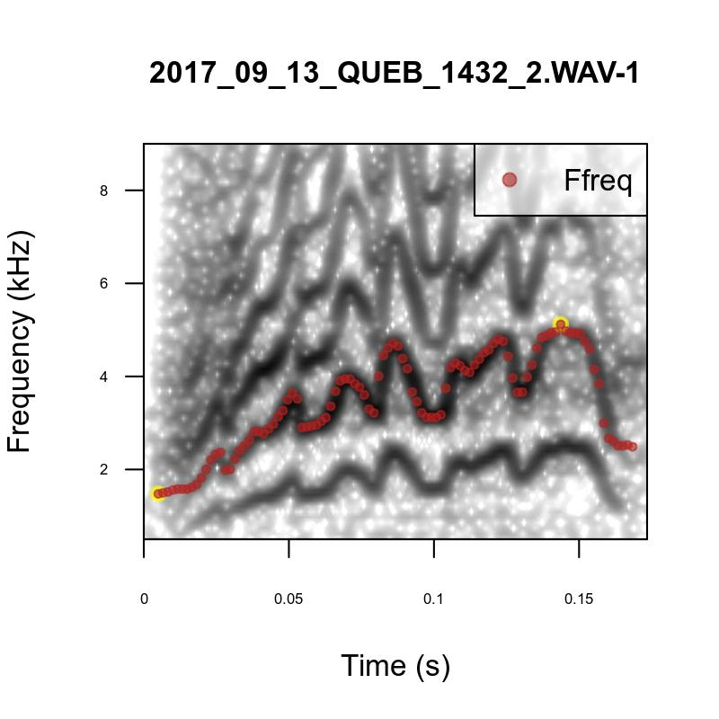

Second harmonic contour

Saved the EST with the final tailored 2nd harmonic traces.

```r
freq_mod_est3 <- freq_mod_est2 %>%
  dplyr::select(-c(n_calls))

saveRDS(freq_mod_est3, file.path(path, "freq_mod_est_m2h.RDS"))

# Save as a .csv as well for sharing data
write.csv(freq_mod_est3, file.path(path, "freq_mod_est_m2h.csv"), row.names = FALSE)
```

# Frequency modulation measurements

Read in the EST (a unique sound file per row) and the data frame with calls allocated for different analyses (sound files per row, with 6 shared across intended spatial and temporal comparisons as described above).

```r
# The EST with the manually tailored 2nd harmonic traces
freq_mod_est <- readRDS(file.path(path, "freq_mod_est_m2h.RDS"))
# freq_mod_est <- read.csv(file.path(path, "freq_mod_est_m2h.csv"))
# glimpse(freq_mod_est)

# Read in the data frame with used for each question/comparison (some calls used for both spatial and temporal question, only 6 total)
freq_modQ_df <- readRDS(file.path(path, "freq_mod_df.RDS"))
# freq_modQ_df <- read.csv(file.path(path, "freq_mod_df.csv"))
# glimpse(freq_modQ_df)
```

## Initial peak searching routine

Randomly select 5 calls per range to groundtruth a peak searching method. First, make visuals of each call, then manually count peaks.

```r
freq_mod_est2 <- freq_mod_est %>%
  as_tibble()

# Randomly select 5 site-scale calls per range
set.seed(seed)
calls <- freq_mod_est2 %>%
  filter(social_scale == "Site") %>%
  group_by(range) %>%
  nest() %>%
  ungroup() %>%
  dplyr::mutate(
    rsamp_calls = purrr::map2(data, 5, sample_n, replace = FALSE)
  ) %>%
  dplyr::select(-data) %>%
  unnest(rsamp_calls) %>%
  pull(sound.files) %>%
  as.character()
calls

tmp_df <- freq_mod_est2 %>%
  filter(sound.files %in% calls) %>%
  droplevels()

n_tot <- 100 # the number of timepoints per frequency trace
n_rem <- 5 # remove 5 points at the start and end of each call, for 90 frequency measurements total across each call
# the number of timepoints per frequency trace, minus 5 on either end
n <- n_tot - (n_rem*2)
n

# Make visuals of the frequency traces of these calls to count peaks
dev.off()
invisible(pblapply(1:nrow(tmp_df), function(i){

  # Get the frequency trace for the given call
  tmp <- tmp_df[i, ]
  # glimpse(tmp)

  # Drop 5 points on either end
  tmp <- tmp[, -grep(paste(paste("^", paste("ffreq", c(seq(1, n_rem, 1), seq(n_tot - n_rem + 1, n_tot, 1)), sep = "."), "$", sep = ""), collapse = "|"), names(tmp))]
  # glimpse(tmp)

  # Get the frequency trace as a vector
  ftrace <- as.vector(t(tmp[, grep("ffreq", names(tmp))]))

   jpeg(file.path(gpath, paste(tmp_df$sound.files[i], "count_peaks.jpeg", sep = "-")), units = "in", width = 5, height = 4, res = 200)
  plot(ftrace)
  lines(ftrace, col = "red")
  dev.off()

}))

tmp_df$sound.files

# Sound file                              # "Large" peaks  # Troughs following peaks
# [1] "2011_02_15_PLEA_WRIG1012_3.WAV"    # 4             # 3
#  [2] "2011_02_18_LAKE_WRIG1039_10.WAV"    # 5           # 5
#  [3] "SBD_Austin.1002.0180_resamp.WAV"    # 5           # 3
#  [4] "SBD_NewOrleans.1006.0493_resamp.WAV" # 5          # 4
#  [5] "2017_05_21_PLVE_1005_6.WAV"       # 8             # 7
#  [6] "2017_10_25_PIED_1561_2.WAV"       # 7             # 6
#  [7] "2017_09_13_ELTE_1405_3.WAV"     # 5               # 5
#  [8] "2017_09_03_INBR_1269_3.WAV"       # 6             # 5
#  [9] "2017_11_20_GOLF_1644_1.WAV"       #  6            # 5
# [10] "2011_02_15_ELEM_WRIG1013_4.WAV" # 4               # 3

# Add these vaues to the temporary data frame
tmp_df$mnl_pks <- c(4, 5, 5, 5, 8, 7, 5, 6, 6, 4)
tmp_df$mnl_trghs <- c(3, 5, 3, 4, 7, 6, 5, 5, 5, 3)
```

Find peaks across these calls using a general peak search method. These peaks will be used as a rough estimate of peak size, to impose a threshold on minimum peak size later on the magnitude of peaks with respect to local points. Use the peak searching code to also identify troughs, by inverting the frequency trace.

```r
n_tot <- 100 # the number of timepoints per frequency trace
n_rem <- 5 # remove 5 points at the start and end of each call, for 90 frequency measurements total across each call
# the number of timepoints per frequency trace, minus 5 on either end
n <- n_tot - (n_rem*2)
n

nups <- 2
ndowns <- 0
minpeakheight <- 1 # 1 kHz as min peak height
zero <- "0"

pk_hght_df <- rbindlist(pblapply(1:nrow(tmp_df), function(i){

  # Get the frequency trace for the given call
  tmp <- tmp_df[i, ]
  # glimpse(tmp)

  # Drop 5 points on either end
  tmp <- tmp[, -grep(paste(paste("^", paste("ffreq", c(seq(1, n_rem, 1), seq(n_tot - n_rem + 1, n_tot, 1)), sep = "."), "$", sep = ""), collapse = "|"), names(tmp))]
  # glimpse(tmp)

  # Get the frequency trace as a vector
  ftrace <- as.vector(t(tmp[, grep("ffreq", names(tmp))]))

  pks <- findpeaks(ftrace, nups = nups, ndowns = ndowns, zero = zero, minpeakheight = minpeakheight)

  return(data.frame(sound.files = tmp_df$sound.files[i], range = tmp_df$range[i], peak_number = seq(1, nrow(pks), 1), peak_height = pks[, 1], peak_max_index = pks[, 2]))

}))

glimpse(pk_hght_df)
max(pk_hght_df$peak_height)
```

Next, I customized this routine again to locate peaks that picks up large peaks but not gradual increases. Used the dataset of 10 randomly selected calls above for ground truthing, with spline-smoothing, and determine the degree of smoothing that yields results closest to visual inspection of peaks, as well as good detection of troughs (inverted peaks). Then moved on to identifying peaks across all calls with frequency traces for the spatial and temporal questions.

```r
n_tot <- 100 # the number of timepoints per frequency trace
n_rem <- 5 # remove 5 points at the start and end of each call, for 90 frequency measurements total across each call
# the number of timepoints per frequency trace, minus 5 on either end
n <- n_tot - (n_rem*2)
n

nups <- 2
ndowns <- 0
minpeakheight <- 1 # 1 kHz as min peak height
zero <- "0"

# Degrees of freedom for smoothing
dfs <- seq(25, 125, 25)
dfs

# Impose a threshold for minimum peak rise with respect to local neigboring points before it
# This is 1/100th of the maximum peak height determined above with this subset of calls
thresh <- round(max(pk_hght_df$peak_height)/100, 1)
thresh # 0.1

# Iterate over calls and degrees of freedom for smoothing
# i <- 1
# j <- 1
pks_gt <- rbindlist(pblapply(1:nrow(tmp_df), function(i){

  tmp2 <- rbindlist(lapply(1:length(dfs), function(j){

    # Get the frequency trace for the given call
    tmp <- tmp_df[i, ]
    # glimpse(tmp)

    # Drop 5 points on either end
    tmp <- tmp[, -grep(paste(paste("^", paste("ffreq", c(seq(1, n_rem, 1), seq(n_tot - n_rem + 1, n_tot, 1)), sep = "."), "$", sep = ""), collapse = "|"), names(tmp))]
    # glimpse(tmp)

    # Get the frequency trace as a vector
    ftrace <- as.vector(t(tmp[, grep("ffreq", names(tmp))]))
    # ftrace

    # Fit a spline and smooth it, to remove small local maxima arising from manual tracing
    # Interpolate a total of n equally spaced values (here 5 times the length of the trace), take the mean of tied x-values
    splf <- spline(ftrace, n = 5*length(ftrace), method = "fmm")
    # str(splf)
    # plot(splf)
    # plot(ftrace)

    # Perform spline smoothing without weighting. Here, df represents the degree of smoothing. Higher values of df lead to less smoothing
    splf_smooth <- smooth.spline(splf, df = dfs[j])
    # str(splf_smooth)
    # plot(splf_smooth)
    # plot(splf)

    # Output is a matrix, each row is a peak found, first column is the height, second column is the index of the vector where the maximum is reached, then the third and fourth are the indices where the peak starts and ends
    pks <- findpeaks(splf_smooth$y, nups = nups, ndowns = ndowns, zero = zero, minpeakheight = minpeakheight)
    # pks
    # str(pks)

    # Impose additional filters on the peaks:
    # 1) Remove "peaks" identified within the last 2 points of the trace
    # 2) Remove peaks with maximum values that are less than 0.1kHz than the frequency value 5 points before (if the given peak 5 points or less from the beginning, remove peaks that are less than the threshold than the point before)
    # 3) Remove peaks identified close together (less than 5 points apart) that are probably points on the same wide peak

    rem1 <- which(pks[, 2] > (length(splf_smooth$x) - 2))
    # rem1

    if(length(rem1) > 0){
      pks <- pks[-rem1, ]
    }

    # z <- 1
    rem2 <- unlist(lapply(1:nrow(pks), function(z){

      # cat(paste("z = ", z, "\n"))

      indx <- pks[z, 2]
      idiff <- indx - 10

      if(!idiff < 0 & idiff != 0){
        rel_ht <- pks[z, 1] - splf_smooth$y[idiff]
        if(rel_ht < thresh){
          return(z)
        }
      } else {
        idiff <- indx - 1
        rel_ht <- pks[z, 1] - splf_smooth$y[idiff]
        if(rel_ht < thresh){
          return(z)
        }
      }

    }))
    # rem2
    # pks

    # Remove these indices from the peaks
    if(length(rem2) > 0){
      pks <- pks[-rem2, ]
    }

    # If more than one peak remains, find those that are too close together (5 points or less)
    if(is.matrix(pks) & nrow(pks) > 0){
      rem3 <- which(diff(pks[, 2]) < 5)
      if(length(rem3) > 0){
        pks <- pks[-rem3, ]
      }
    }

    # Return the number of peaks
    if(is.matrix(pks)){
      num_peaks = nrow(pks)
    } else {
      num_peaks = length(pks)
    }

    # Identify troughs by applying the findpeaks code to the inverted frequency trace
    # Removed the minpeakheight limitation here
    trghs <- findpeaks(-splf_smooth$y, nups = nups, ndowns = ndowns, zero = zero)
    # trghs
    # str(trghs)

    # Filter the troughs to retain those following the peaks identified above
    # In other words, assign each trough to a peak, and drop troughs without matches
    # Do the peak-trough assignments by finding the closest trough following each peak

    # If more than one peak was identified for the given call
    if(is.matrix(pks) & nrow(pks) > 0){

      trough_df <- rbindlist(lapply(1:nrow(pks), function(z){
        # Get the difference in indices between the given peak and all troughs
        diff_inds <- pks[z, 2] - trghs[, 2]
        # Find the negative differences (trough following a peak), and the max of these
        wh <- which(diff_inds < 0 & diff_inds == max(diff_inds[diff_inds < 0]))

        return(data.frame(peak_indx = pks[z, 2], trgh_indx = trghs[wh, 2]))
      }))

      # If only a single peak was identified per call
      } else if(!is.matrix(pks) & nrow(pks) == 0){

        # Get the difference in indices between the given peak and all troughs
        diff_inds <- pks[2] - trghs[, 2]
        # Find the negative differences (trough following a peak), and the max of these
        wh <- which(diff_inds < 0 & diff_inds == max(diff_inds[diff_inds < 0]))

        trough_df <- data.frame(peak_indx = pks[2], trgh_indx = trghs[wh, 2])

      }

    # Return the degree of smoothing and number of peaks
    return(data.frame(sound.files = tmp_df$sound.files[i], range = tmp_df$range[i], num_peaks = nrow(pks), num_trghs = nrow(trough_df), mnl_num_peaks = tmp_df$mnl_pks[i], mnl_num_trghs = tmp_df$mnl_trghs[i], smooth_param = dfs[j]))

    }))

  return(tmp2)

}))

glimpse(pks_gt)
# View(pks_gt)

# Calculate the difference in peaks per call and smoothing parameter compared to the visually identified peaks and troughs, then find the sum of differences per smoothing parameter
pks_gt %>%
  dplyr::mutate(
    numdiffp = abs(num_peaks - mnl_num_peaks),
    numdifft = abs(num_trghs - mnl_num_trghs)
  ) %>%
  group_by(smooth_param) %>%
  dplyr::summarise(
    sumdiffp = sum(numdiffp),
    sumdifft = sum(numdifft)
  )

# smooth_param (df in smooth.spline) of 50 had the least number of differences in peaks identified compared to visual inspection, and more troughs. More of the measurements below depend on better peak estimates, so decided to proceed with smoothing parameter of 50
```

## Final customized peak and trough routine

Make the code above into a function, then checked out the peaks identified across the groundtruthing calls with this smoothing threshold. I improved the peak and trough searching in this function compared to the code above.

```r
peak_locator <- function(X, n_tot, n_rem, degf, nups, ndowns, minpeakheight, zero, thresh, img, neighb, pkdist){

  tmp_df <- rbindlist(pblapply(1:nrow(X), function(i){

    # The number of timepoints per frequency trace, minus 5 on either end
    n <- n_tot - (n_rem*2)

    # Get the frequency trace for the given call
    tmp <- X[i, ]

    # Drop 5 points on either end
    tmp <- tmp[, -grep(paste(paste("^", paste("ffreq", c(seq(1, n_rem, 1), seq(n_tot - n_rem + 1, n_tot, 1)), sep = "."), "$", sep = ""), collapse = "|"), names(tmp))]

    # Get the frequency trace as a vector
    ftrace <- as.vector(t(tmp[, grep("ffreq", names(tmp))]))

    # Fit a spline and smooth it, to remove small local maxima arising from manual tracing
    # Interpolate a total of n equally spaced values (here 5 times the length of the trace), take the mean of tied x-values
    splf <- spline(ftrace, n = 5*length(ftrace), method = "fmm")

    # Perform spline smoothing without weighting. Here, df represents the degree of smoothing. Higher values of df lead to less smoothing
    splf_smooth <- smooth.spline(splf, df = degf)

    # Output is a matrix, each row is a peak found, first column is the height, second column is the index of the vector where the maximum is reached, then the third and fourth are the indices where the peak starts and ends
    pks <- findpeaks(splf_smooth$y, nups = nups, ndowns = ndowns, zero = zero, minpeakheight = minpeakheight)
    # pks
    # str(pks)

    # Impose additional filters on the peaks:
    # 1) Remove "peaks" identified within the last 2 points of the trace
    # 2) Remove peaks with maximum values that when compared to the frequency value of neighoring points before have a difference of less than the given threshold (if the given peak is the number of neighboring points or less from the beginning, compare to neighbors within half the distance of the index from the start point)
    # 3) Remove peaks identified close together that are probably points on the same wide peak

    rem1 <- which(pks[, 2] > (length(splf_smooth$x) - 2))

    if(length(rem1) > 0){
      pks <- pks[-rem1, ]
    }

    rem2 <- unlist(lapply(1:nrow(pks), function(z){

      indx <- pks[z, 2]
      idiff <- indx - neighb

      if(!idiff < 0 & idiff != 0){
        rel_ht <- pks[z, 1] - splf_smooth$y[idiff]
        if(rel_ht < thresh){
          return(z)
        }
      } else {
        idiff <- indx - (indx/2)
        rel_ht <- pks[z, 1] - splf_smooth$y[idiff]
        if(rel_ht < thresh){
          return(z)
        }
      }

    }))

    # Remove these indices from the peaks
    if(length(rem2) > 0){
      pks <- pks[-rem2, ]
    }

    # If more than one peak remains, find those that are too close together
    if(is.matrix(pks) & nrow(pks) > 0){
      rem3 <- which(diff(pks[, 2]) < pkdist)
      if(length(rem3) > 0){
        pks <- pks[-rem3, ]
      }
    }

    # Identify troughs by applying the findpeaks code to the inverted frequency trace
    # Removed the minpeakheight limitation here
    trghs <- findpeaks(-splf_smooth$y, nups = nups, ndowns = ndowns, zero = zero)

    # Filter the troughs to retain those following the peaks identified above
    # In other words, assign each trough to a peak, and drop troughs without matches
    # Do the peak-trough assignments by finding the closest trough following each peak

    # If more than one peak was identified for the given call
    if(is.matrix(pks) & nrow(pks) > 0){

      trough_df <- rbindlist(lapply(1:nrow(pks), function(z){

        # Get the difference in indices between the given peak and all troughs
        diff_inds <- pks[z, 2] - trghs[, 2]

        # Find the negative differences (trough following a peak)
        negs <- diff_inds[diff_inds < 0]

        # Check whether there are 2 troughs between this peak and the next
        # If so, return the deepest trough, to account for tall peaks with shoulders that drop lower after the shoulder
        if(z != nrow(pks) & z > 1){

          neigh_trghs <- which(trghs[, 2] >= pks[z, 2] & trghs[, 2] <= pks[z + 1, 2])
          # If there are neighboring troughs prior to the next peak, and the first trough is not as deep as the following troughs, find which of the following troughs is the deepest

          if(length(neigh_trghs) > 1 & all(trghs[neigh_trghs[1], 1] < trghs[neigh_trghs[-1], 1]) & length(negs) > 0){

            wh <- which(diff_inds < 0 & seq(1, nrow(trghs), 1) %in% neigh_trghs & diff_inds == min(diff_inds[seq(1, nrow(trghs), 1) %in% neigh_trghs]))

            # If there are neighboring troughs prior to the next peak, but the first trough is deeper than the following troughs, get this first trough
          } else if(length(neigh_trghs) > 1 & all(trghs[neigh_trghs[1], 1] > trghs[neigh_trghs[-1], 1]) & length(negs) > 0){

            wh <- neigh_trghs[1]

          # Else if there's just a single trough identified between peaks
          } else if(length(neigh_trghs) == 1 & length(negs) > 0){

            wh <- which(diff_inds < 0 & diff_inds == max(negs, na.rm = TRUE))

          # Else if no neighboring trough is identified for the given peak
          } else if(length(neigh_trghs) == 0){

            wh <- NULL
          }

        # Else if on the first or last peak, just a single trough or none should be identified
        } else if(z == nrow(pks) | z == 1 & length(negs) > 0){

          if(length(negs) > 0){
            wh <- which(diff_inds < 0 & diff_inds == max(negs, na.rm = TRUE))
          } else {
            wh <- NULL
          }

        }

        # Return a data frame with the slope of the frequency curve between the peak and its matching trough, unless the peak wasn't matched to a trough (e.g. a peak close to the end of a call)
        if(length(wh) > 0){

          pt_slope <- (splf_smooth$y[trghs[wh, 2]] - splf_smooth$y[pks[z, 2]])/(splf_smooth$x[trghs[wh, 2]] - splf_smooth$x[pks[z, 2]])

          # Make sure to convert the trough heights back to positive values here
          return(data.frame(peak_indx = pks[z, 2], trgh_indx = trghs[wh, 2], trgh_hght = -trghs[wh, 1], pt_slope = pt_slope))

        } else{

          return(data.frame(peak_indx = pks[z, 2], trgh_indx = NA, trgh_hght = NA, pt_slope = NA))
        }

      }))

      # If only a single peak was identified per call
      } else if(!is.matrix(pks) & nrow(pks) == 0){

        # Get the difference in indices between the given peak and all troughs
        diff_inds <- pks[2] - trghs[, 2]

        # Find the negative differences (trough following a peak), and the max of these if troughs were found
        negs <- diff_inds[diff_inds < 0]

        if(length(negs) > 0){
          wh <- which(diff_inds < 0 & diff_inds == max(negs, na.rm = TRUE))
        } else {
          wh <- NULL
        }
        # Return a data frame with the difference in height between the peak and its matching trough
        if(length(wh) > 0){

          (splf_smooth$y[trghs[wh, 2]] - splf_smooth$y[pks[2]])/(splf_smooth$x[trghs[wh, 2]] - splf_smooth$x[pks[2]])

          return(data.frame(peak_indx = pks[2], trgh_indx = trghs[wh, 2], trgh_hght = -trghs[wh, 1], pt_slope = pt_slope))

        } else{
          return(data.frame(peak_indx = pks[z, 2], trgh_indx = NA, trgh_hght = NA, pt_slope = NA))
        }

      }

    # If img = TRUE, generate an image file with the peaks and troughs
    if(img){
      jpeg(file.path(gpath, paste(X$sound.files[i], "freq_peaks.jpeg", sep = "-")), units = "in", width = 5, height = 4, res = 200)
      plot(splf_smooth$y)
      points(x = pks[, 2], y = pks[, 1], pch = 4, cex = 2, col = "red")
      points(x = trough_df$trgh_indx, y = trough_df$trgh_hght, pch = 4, cex = 2, col = "blue")
      dev.off()
    }

    # Return the peaks found per call, the rate of change, and the change in frequency between matched peaks and troughs
    return(data.frame(
      sound.files = X$sound.files[i],
      range = X$range[i],
      site = X$site[i],
      year = X$year[i],
      site_year = X$site_year[i],
      region = X$region[i],
      dept_state = X$dept_state[i],
      invasive_city = X$invasive_city[i],
      peak_number = seq(1, nrow(pks), 1),
      peak_height = pks[, 1],
      peak_max_index = pks[, 2],
      peak_start_index = pks[, 3],
      peak_end_index = pks[, 4],
      peak_trgh_slope = trough_df$pt_slope,
      trgh_index = trough_df$trgh_indx
      )
    )

  }))

  return(tmp_df)
}

# Used the resulting image files to visually assess how well this customized routine picks up large peaks and neighboring troughs
peak_res <- peak_locator(X = tmp_df, n_tot = 100, n_rem = 5, nups = 2, ndowns = 0, minpeakheight = 1, zero = "0", degf = 50, thresh = 0.05, img = TRUE, neighb = 25, pkdist = 20)
# glimpse(peak_res)
```

This peak locator function performed well in locating large frequency peaks, and some smaller ones for the reduced call dataset. Each peak was matched pretty well with a following trough. For some wider peaks, the trough comes somewhat late, but overall still looks great for final analysis. Future work could take into account the width of peaks as well.

Next, checked peaks identified for all calls for which we performed frequency tracing. Here, I checked that all large visible peaks had been identified using the same parameters as for the subset of calls above. A handful of calls had one peak not identified, but these peak were medium-sized and typically nested right in between larger peaks (more difficult to identify). Other calls had smaller peaks identified. Overall, the function picked up large modulation peaks per call, and results looked good to continue (see example image file below).

```r
freq_mod_df <- freq_modQ_df %>%
  inner_join(
    freq_mod_est %>%
      as.data.frame() %>%
      dplyr::select(names(freq_mod_est)[grep("sound.files|ffreq", names(freq_mod_est))]),
    by = "sound.files"
  ) %>%
  droplevels() %>%
  # Remove duplicated sound files chosen for both spatial and temporal comparisons
  filter(!duplicated(sound.files))
# glimpse(freq_mod_df)
nrow(freq_mod_df)
```

```
## [1] 233
```

### Frequency modulation measurements

```r
peaks_troughs_df <- peak_locator(X = freq_mod_df, n_tot = 100, n_rem = 5, nups = 2, ndowns = 0, minpeakheight = 1, zero = "0", degf = 50, thresh = 0.05, img = TRUE, neighb = 25, pkdist = 20)
glimpse(peaks_troughs_df)

# Save this data for use later as needed
saveRDS(peaks_troughs_df, file.path(path, "peaks_troughs_df.RDS"))

# Save as a .csv as well for sharing data
write.csv(peaks_troughs_df, file.path(path, "peaks_troughs_df.csv"), row.names = FALSE)
```

### Visual validation

The image files look great. Nearly every peak was assigned a trough. Some intermediate peaks close to larger peaks were picked up, and some more gradual increases were picked up as peaks, but overall, the function did a good job with identfying large, visible peaks and troughs across all calls for which we performed frequency tracing.

### AM3.2

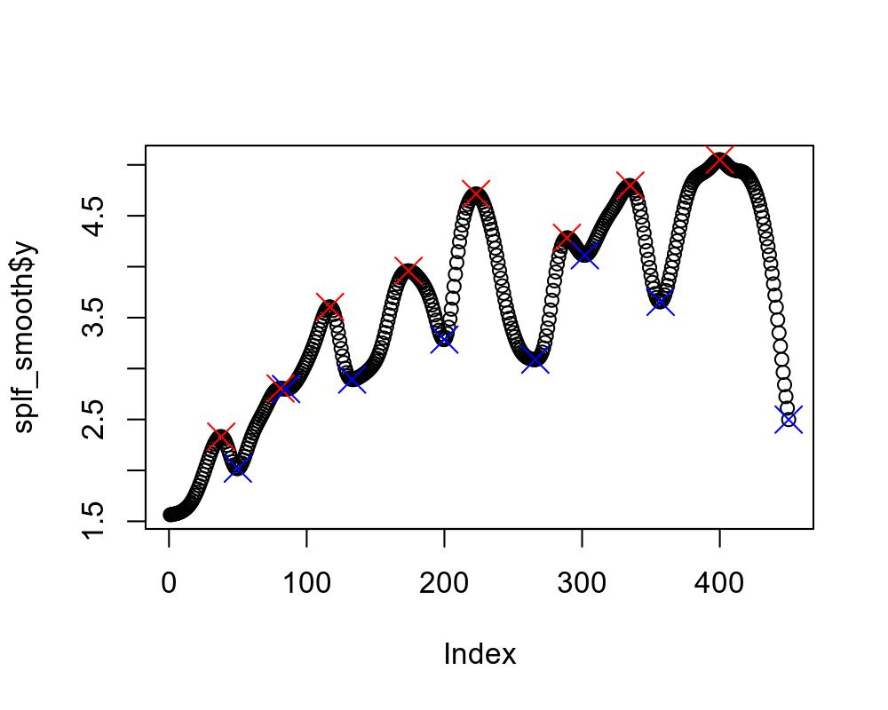

Spline-smoothed contour with peaks and troughs for 2017_09_13_QUEB_1432_2.WAV

I performed a final found of filtering using the frequency modulation measurements for the full dataset prior to parsing out calls chosen above for the spatial comparison between ranges.

```r
# The function returns one row per peak, with trough information per row
# Dropping peaks below will therefore drop associated trough information
peaks_trghs_df <- readRDS(file.path(path, "peaks_troughs_df.RDS"))
# peaks_trghs_df <- read.csv(file.path(path, "peaks_troughs_df.csv"))
glimpse(peaks_trghs_df)
```

```
## Rows: 1,309
## Columns: 15
## $ sound.files      <fct> 2017_07_11_INES-04_MZ000149_1.WAV, 2017_07_11_INES-0…
## $ range            <fct> Native, Native, Native, Native, Native, Native, Nati…
## $ site             <fct> INES-04, INES-04, INES-04, INES-04, INES-04, INES-04…
## $ year             <fct> 2017, 2017, 2017, 2017, 2017, 2017, 2017, 2017, 2017…
## $ site_year        <fct> INES-04_2017, INES-04_2017, INES-04_2017, INES-04_20…
## $ region           <fct> West, West, West, West, West, West, West, West, West…
## $ dept_state       <fct> Colonia, Colonia, Colonia, Colonia, Colonia, Colonia…
## $ invasive_city    <fct> NA, NA, NA, NA, NA, NA, NA, NA, NA, NA, NA, NA, NA, …
## $ peak_number      <dbl> 1, 2, 3, 4, 5, 6, 7, 1, 2, 3, 4, 5, 6, 7, 1, 2, 3, 4…
## $ peak_height      <dbl> 2.677283, 4.936604, 4.949482, 4.875870, 5.060024, 4.…
## $ peak_max_index   <dbl> 46, 108, 150, 203, 256, 304, 364, 53, 87, 144, 203, …
## $ peak_start_index <dbl> 1, 54, 125, 176, 229, 280, 352, 1, 59, 116, 167, 226…
## $ peak_end_index   <dbl> 54, 125, 176, 229, 280, 339, 443, 59, 116, 167, 226,…
## $ peak_trgh_slope  <dbl> -0.016857731, -0.395336964, -0.336700987, -0.3574647…
## $ trgh_index       <dbl> 54, 125, 176, 229, 280, 339, 443, 59, 116, 167, 226,…
```

```r
# How many peaks in this dataset weren't matched to troughs? 2
length(which(is.na(peaks_trghs_df$peak_trgh_slope)))
```

```
## [1] 2
```

```r
# Remove these for distribution calculations below
peaks_trghs_df2 <- peaks_trghs_df %>%
  filter(!is.na(peak_trgh_slope)) %>%
  droplevels()

# What is the distribution of peak - trough ranges? Can this be used to exclude smaller peaks?
range(peaks_trghs_df2$peak_trgh_slope, na.rm = TRUE)
```

```
## [1] -0.90275383  0.01155562
```

```r
# hist(peaks_trghs_df2$peak_trgh_slope, breaks = 50)

# Yes, if we split these distances into 50 bins (yields similar results to 100 intervals), then discard the last two bins of slopes, which represent the smallest peaks
levels(cut(peaks_trghs_df2$peak_trgh_slope, 50))
```

```
##  [1] "(-0.904,-0.884]"   "(-0.884,-0.866]"   "(-0.866,-0.848]"
##  [4] "(-0.848,-0.83]"    "(-0.83,-0.811]"    "(-0.811,-0.793]"
##  [7] "(-0.793,-0.775]"   "(-0.775,-0.756]"   "(-0.756,-0.738]"
## [10] "(-0.738,-0.72]"    "(-0.72,-0.702]"    "(-0.702,-0.683]"
## [13] "(-0.683,-0.665]"   "(-0.665,-0.647]"   "(-0.647,-0.628]"
## [16] "(-0.628,-0.61]"    "(-0.61,-0.592]"    "(-0.592,-0.574]"
## [19] "(-0.574,-0.555]"   "(-0.555,-0.537]"   "(-0.537,-0.519]"
## [22] "(-0.519,-0.5]"     "(-0.5,-0.482]"     "(-0.482,-0.464]"
## [25] "(-0.464,-0.446]"   "(-0.446,-0.427]"   "(-0.427,-0.409]"
## [28] "(-0.409,-0.391]"   "(-0.391,-0.372]"   "(-0.372,-0.354]"
## [31] "(-0.354,-0.336]"   "(-0.336,-0.318]"   "(-0.318,-0.299]"
## [34] "(-0.299,-0.281]"   "(-0.281,-0.263]"   "(-0.263,-0.244]"
## [37] "(-0.244,-0.226]"   "(-0.226,-0.208]"   "(-0.208,-0.19]"
## [40] "(-0.19,-0.171]"    "(-0.171,-0.153]"   "(-0.153,-0.135]"
## [43] "(-0.135,-0.116]"   "(-0.116,-0.0982]"  "(-0.0982,-0.0799]"
## [46] "(-0.0799,-0.0616]" "(-0.0616,-0.0433]" "(-0.0433,-0.025]"
## [49] "(-0.025,-0.00673]" "(-0.00673,0.0125]"
```

```r
# Add these bins back to the data frame, then drop peaks that fell into the first interval
peaks_trghs_df2$peak_size_class <- cut(peaks_trghs_df2$peak_trgh_slope, 50, labels = FALSE)

# Numbers of peaks by interval
# 160 peaks will be dropped after excluding peaks in the last two bins
table(peaks_trghs_df2$peak_size_class)
```

```
##
##  1 11 12 13 15 17 18 19 20 21 22 23 24 25 26 27 28 29 30 31 32 33 34 35 36 37
##  1  1  1  2  1  1  1  1  3  3  6  9 12  9  8 17 28 25 25 33 46 52 61 50 76 69
## 38 39 40 41 42 43 44 45 46 47 48 49 50
## 94 81 80 58 55 42 54 28 31 31 52 95 65
```

```r
# Exclude peaks in the first 3 height bins
peaks_trghs_df3 <- peaks_trghs_df2 %>%
  dplyr::mutate(
    peak_size_class = as.numeric(peak_size_class)
  ) %>%
  filter(peak_size_class < 49) %>%
  droplevels() %>%
  # Remove the peak_size_class column
  dplyr::select(-c(peak_size_class)) %>%
  # Add back the peaks that were not assigned to troughs
  bind_rows(
    peaks_trghs_df %>%
    filter(is.na(peak_trgh_slope)) %>%
    droplevels()
  )

# 1149 peaks remain, 160 were removed, looks great
nrow(peaks_trghs_df3)
```

```
## [1] 1149
```

```r
nrow(peaks_trghs_df) - nrow(peaks_trghs_df3)
```

```
## [1] 160
```

## Comparison between ranges

Obtained frequency modulation measurements and a standard set of acoustic parameters for the calls set aside for the spatial comparison between ranges.

```r
calls <- freq_modQ_df %>%
  filter(question == "spatial") %>%
  pull(sound.files) %>%
  as.character()

length(calls)
```

```
## [1] 80
```

```r
peaks_spat_df <- peaks_trghs_df3 %>%
  filter(sound.files %in% calls) %>%
  droplevels()
# glimpse(peaks_spat_df)

# 40 native range calls, 40 invasive range calls, each call represents a "unique" individual
# 4 randomly sampled calls from 10 randomly sites per range
peaks_spat_df %>%
  group_by(range) %>%
  dplyr::summarise(
    n_calls = n_distinct(sound.files)
  )
```

```
## # A tibble: 2 x 2
##   range    n_calls
##   <fct>      <int>
## 1 Native        40
## 2 Invasive      40
```

```r
# How many years are represented in the invasive range? More calls from 2004, but some from each 2011 and 2019
peaks_spat_df %>%
  filter(range == "Invasive") %>%
  group_by(year) %>%
  dplyr::summarise(
    n_calls = n_distinct(sound.files)
  )
```

```
## # A tibble: 3 x 2
##   year  n_calls
##   <chr>   <int>
## 1 2004       24
## 2 2011        8
## 3 2019        8
```

```r
# Native spatial areas represented?
peaks_spat_df %>%
  filter(range == "Native") %>%
  group_by(region, dept_state) %>%
  dplyr::summarise(
    n_calls = n_distinct(sound.files)
  )
```

```
## # A tibble: 5 x 3
## # Groups:   region [3]
##   region  dept_state n_calls
##   <chr>   <chr>        <int>
## 1 Central Canelones        4
## 2 Central Montevideo       8
## 3 East    Maldonado       12
## 4 East    San Jose         4
## 5 West    Colonia         12
```

```r
# Which native range sites? None of these had known repeatedly sampled individuals
peaks_spat_df %>%
  filter(range == "Native") %>%
  group_by(site) %>%
  dplyr::summarise(
    n_calls = n_distinct(sound.files)
  )
```

```
## # A tibble: 10 x 2
##    site    n_calls
##    <chr>     <int>
##  1 ELTE          4
##  2 FAGR          4
##  3 GOLF          4
##  4 INBR          4
##  5 INES-04       4
##  6 INES-08       4
##  7 PAVO          4
##  8 PIED          4
##  9 PLVE          4
## 10 QUEB          4
```

```r
# Invasive spatial areas represented?
# More representation from Texas, as expected
peaks_spat_df %>%
  filter(range == "Invasive") %>%
  group_by(region, dept_state) %>%
  dplyr::summarise(
    n_calls = n_distinct(sound.files)
  )
```

```
## # A tibble: 4 x 3
## # Groups:   region [3]
##   region    dept_state  n_calls
##   <chr>     <chr>         <int>
## 1 Northeast Connecticut       8
## 2 Southeast Florida           4
## 3 Southeast Louisiana         4
## 4 Southwest Texas            24
```

```r
# Which inasvive range site-years?
# We recorded repeatedly sampled individuals at some of these sites
# But calls from repeatedly sampled individuals used in the final dataset are not included here (see below)
peaks_spat_df %>%
  filter(range == "Invasive") %>%
  group_by(site_year) %>%
  dplyr::summarise(
    n_calls = n_distinct(sound.files)
  )
```

```
## # A tibble: 10 x 2
##    site_year n_calls
##    <chr>       <int>
##  1 AIRP_2019       4
##  2 AUDU_2004       4
##  3 BALL_2004       4
##  4 BAPT_2004       4
##  5 INTR_2011       4
##  6 MANO_2019       4
##  7 SHAK_2004       4
##  8 SOCC_2004       4
##  9 SOFT_2011       4
## 10 VALL_2004       4
```

```r
# Were any calls from known repeatedly sampled individuals used in frequency tracing?
# Yes, but these 2 calls are from birds that were not retained as repeatedly sampled individuals in the final dataset (not enough calls remained after pre-processing)
unique(peaks_spat_df$sound.files[grep("site_scale", peaks_spat_df$sound.files)])
```

```
## [1] "2019_08_07_AIRP_GSV1040_8_site_scale.WAV"
## [2] "2019_08_07_AIRP_GSV1043_2_site_scale.WAV"
```

## Frequency modulation summary statistics

Calculated modulation rate, then the mean and standard error of the 3 frequency modulation measurements, as well as the 15 acoustic measurements used in machine learning (see previous script, previously filtered for collinearity), and the number of peaks identified modulation rate, and peak-trough change in frequency per range, for the same calls.

```r
# Iterate over measurements to get summary statistics per range, and effect size of range
ms <- c("Number of peaks", "Modulation rate", "Peak - trough slope")
col_nms <- c("num_peaks", "freq_mod_rate", "peak_trgh_slope")

mean_se_df_fm <- rbindlist(pblapply(1:length(ms), function(i){

  # Get summary statistics and effect sizes depending on measurement type
  if(grepl("Number of peaks", ms[i])){

    tmp_df <- peaks_spat_df %>%
      # Find the number of peaks per call
      group_by(range, sound.files) %>%
      dplyr::summarise(
        num_peaks = length(peak_number)
      ) %>%
      ungroup() %>%
      # Ensure levels of the range column are in the expected order
      dplyr::mutate(
        range = as.character(range),
        range = factor(range, levels = c("Native", "Invasive"))
      ) %>%
      # Calculate mean and standard error per range
      group_by(range) %>%
      dplyr::summarise(
        mean_peaks = mean(num_peaks),
        se_peaks = std_err(num_peaks)
      ) %>%
      # Convert to long format for plotting below
      pivot_longer(
        cols = c(mean_peaks, se_peaks),
        names_to = "type",
        values_to = "values"
      ) %>%
      dplyr::mutate(
        measurement = ms[i],
        statistic = ifelse(grepl("mean", type), "mean_vals", "se_vals")
      ) %>%
      dplyr::select(-c(type)) %>%
      # Make wider to split out the mean and se columns
      pivot_wider(
        names_from = statistic,
        values_from = values
      )

  } else if(grepl("Modulation rate", ms[i])){

    tmp_df <- peaks_spat_df %>%
      # Calculate duration per call
      inner_join(
        freq_mod_df %>%
        dplyr::mutate(
          duration = end - start
        ) %>%
        dplyr::select(sound.files, duration),
        by = "sound.files"
      ) %>%
      # Calculate modulation rate value per call
      group_by(range, sound.files, duration) %>%
      dplyr::summarise(
        num_peaks = length(peak_number)
      ) %>%
      ungroup() %>%
      dplyr::mutate(
        modulation_rate = (num_peaks/duration) # units for rate of change = peaks/second
      ) %>%
      # Ensure levels of the range column are in the expected order
      dplyr::mutate(
        range = as.character(range),
        range = factor(range, levels = c("Native", "Invasive"))
      ) %>%
      # Calculate mean and standard error per range
      group_by(range) %>%
      dplyr::summarise(
        mean_freq_mod_rate = mean(modulation_rate),
        se_freq_mod_rate = std_err(modulation_rate)
      ) %>%
      # Convert to long format for plotting below
      pivot_longer(
        cols = c(mean_freq_mod_rate, se_freq_mod_rate),
        names_to = "type",
        values_to = "values"
      ) %>%
      dplyr::mutate(
        measurement = ms[i],
        statistic = ifelse(grepl("mean", type), "mean_vals", "se_vals")
      ) %>%
      dplyr::select(-c(type)) %>%
      # Make wider to split out the mean and se columns
      pivot_wider(
        names_from = statistic,
        values_from = values
      )

  } else if(grepl("Peak - trough slope", ms[i])){

    tmp_df <- peaks_spat_df %>%
      # Drop peaks that were not matched to troughs
      filter(!is.na(peak_trgh_slope)) %>%
      # Ensure levels of the range column are in the expected order
      dplyr::mutate(
        range = as.character(range),
        range = factor(range, levels = c("Native", "Invasive"))
      ) %>%
      # Get maximum (absolute) peak-trough range per call
      group_by(range, sound.files) %>%
      dplyr::summarise(
        max_peak_trgh_slope = min(peak_trgh_slope)
      ) %>%
      ungroup() %>%
      # Calculate mean and standard error per range
      group_by(range) %>%
      dplyr::summarise(
        mean_pt_slope = mean(max_peak_trgh_slope),
        se_pt_slope = std_err(max_peak_trgh_slope)
      ) %>%
      # Convert to long format for plotting below
      pivot_longer(
        cols = c(mean_pt_slope, se_pt_slope),
        names_to = "type",
        values_to = "values"
      ) %>%
      dplyr::mutate(
        measurement = ms[i],
        statistic = ifelse(grepl("mean", type), "mean_vals", "se_vals")
      ) %>%
      dplyr::select(-c(type)) %>%
      # Make wider to split out the mean and se columns
      pivot_wider(
        names_from = statistic,
        values_from = values
      )
  }

  return(tmp_df)

}))

glimpse(mean_se_df_fm)
```

```
## Rows: 6
## Columns: 4
## $ range       <fct> Native, Invasive, Native, Invasive, Native, Invasive
## $ measurement <chr> "Number of peaks", "Number of peaks", "Modulation rate", …
## $ mean_vals   <dbl> 5.8250000, 4.4500000, 33.6421780, 26.8024715, -0.4277597,…
## $ se_vals     <dbl> 0.13815404, 0.15169977, 0.79127482, 0.86858253, 0.0188178…
```

## Frequency modulation effect sizes

Get effect sizes of range on frequency modulation measurements.

```r
# Iterate over measurement types to return effect sizes and 95% CIs
eff_df_fm <- rbindlist(pblapply(1:length(ms), function(i){

  # Get summary statistics and effect sizes depending on measurement type
  if(grepl("Number", ms[i])){

    tmp_df <- peaks_spat_df %>%
      # Find the number of peaks per call
      group_by(range, sound.files) %>%
      dplyr::summarise(
        num_peaks = length(peak_number)
      ) %>%
      ungroup() %>%
      # Ensure levels of the range column are in the expected order
      dplyr::mutate(
        range = as.character(range),
        range = factor(range, levels = c("Native", "Invasive"))
      )

    d <- tmp_df %>%
        pull(num_peaks)
    f <- tmp_df$range

  } else if(grepl("rate", ms[i])){

    tmp_df <- peaks_spat_df %>%
      # Calculate duration per call
      inner_join(
        freq_mod_df %>%
        dplyr::mutate(
          duration = end - start
        ) %>%
        dplyr::select(sound.files, duration),
        by = "sound.files"
      ) %>%
      # Calculate modulation rate value per call
      group_by(range, sound.files, duration) %>%
      dplyr::summarise(
        num_peaks = length(peak_number)
      ) %>%
      ungroup() %>%
      dplyr::mutate(
        modulation_rate = (num_peaks/duration) # units for rate of change = peaks/second
      ) %>%
      # Ensure levels of the range column are in the expected order
      dplyr::mutate(
        range = as.character(range),
        range = factor(range, levels = c("Native", "Invasive"))
      )

    d <- tmp_df %>%
        pull(modulation_rate)
    f <- tmp_df$range

  } else if(grepl("slope", ms[i])){

    tmp_df <- peaks_spat_df %>%
      # Drop peaks that were not matched to troughs
      filter(!is.na(peak_trgh_slope)) %>%
      # Ensure levels of the range column are in the expected order
      dplyr::mutate(
        range = as.character(range),
        range = factor(range, levels = c("Native", "Invasive"))
      ) %>%
      # Get max peak-trough range per call
      group_by(range, sound.files) %>%
      dplyr::summarise(
        max_peak_trgh_slope = min(peak_trgh_slope)
      ) %>%
      ungroup()

    d <- tmp_df %>%
        pull(max_peak_trgh_slope)
    f <- tmp_df$range
  }

  # Get the effect size of range for the given measurement, plus 95% CIs
  effect_res <- cohen.d(
    d = d,
    f = f,
    pooled = TRUE,
    hedges.correction = FALSE
  )

    # Return a data frame with means, standard errors, and the effect size with 95% CIs
    return(data.frame(
      measurement = ms[i],
      effect_size = effect_res$estimate,
      upper_95_CI = effect_res$conf.int[["upper"]],
      lower_95_CI = effect_res$conf.int[["lower"]]
    ))

}))

glimpse(eff_df_fm)
```

```
## Rows: 3
## Columns: 4
## $ measurement <fct> Number of peaks, Modulation rate, Peak - trough slope
## $ effect_size <dbl> 1.498477, 1.301656, -1.234844
## $ upper_95_CI <dbl> 2.0022590, 1.7917012, -0.7491003
## $ lower_95_CI <dbl> 0.9946941, 0.8116105, -1.7205867
```

## Summary statistics, effect sizes for other measurements

Next get mean and standard error of 15 acoustic measurements used in supervised machine learning, as well as effect sizes of range on each measurement.

```r
# Read in the dataset used for supervised machine learning
sup_ML_df <- readRDS(file.path(path, "sup_ML_fin.RDS"))
dim(sup_ML_df)
```

```
## [1] 1561  206
```

```r
# Get the names of raw acoustic parameters used in supervised learning
pnms <- names(sup_ML_df)[which(sapply(sup_ML_df, is.numeric))]
length(pnms[-grep("MDS|PCA", pnms)])
```

```
## [1] 15
```

```r
pnms[-grep("MDS|PCA", pnms)]
```

```
##  [1] "duration"  "freq.Q75"  "freq.IQR"  "time.Q25"  "kurt"      "sp.ent"
##  [7] "mindom"    "maxdom"    "dfrange"   "modindx"   "startdom"  "enddom"
## [13] "dfslope"   "meanpeakf" "peakf"
```

```r
ss_raw_params_df <- sup_ML_df %>%
  # Filter by calls used in the frequency modulation analysis
  filter(sound.files %in% peaks_spat_df$sound.files) %>%
  dplyr::select(range, pnms[-grep("MDS|PCA", pnms)]) %>%
  # Convert to long format
  pivot_longer(
    cols = names(.)[-grep("^range$", names(.))],
    names_to = "measurement",
    values_to = "values"
  ) %>%
  # Get mean and standard error per acoustic measurement per range
  group_by(range, measurement) %>%
  dplyr::summarise(
    mean_vals = mean(values),
    se_vals = std_err(values)
  ) %>%
  # Convert to long format again for plotting below
  pivot_longer(
    cols = c(mean_vals, se_vals),
    names_to = "type",
    values_to = "values"
  ) %>%
  dplyr::mutate(
    statistic = ifelse(grepl("mean", type), "mean_vals", "se_vals")
  ) %>%
  dplyr::select(-c(type)) %>%
  # Make wider to split out the mean and se columns
  pivot_wider(
    names_from = statistic,
    values_from = values
  ) %>%
  ungroup() %>%
  dplyr::mutate(
    measurement = as.character(measurement),
    range = as.character(range),
    range = factor(range, levels = c("Native", "Invasive"))
  )

glimpse(ss_raw_params_df)
```

```
## Rows: 30
## Columns: 4
## $ range       <fct> Invasive, Invasive, Invasive, Invasive, Invasive, Invasiv…
## $ measurement <chr> "dfrange", "dfslope", "duration", "enddom", "freq.IQR", "…
## $ mean_vals   <dbl> 4.68201754, 2.08079716, 0.16650465, 2.08771930, 2.3493077…
## $ se_vals     <dbl> 0.1821249690, 1.8661772267, 0.0025938077, 0.2699759355, 0…
```

```r
levels(ss_raw_params_df$range)
```

```
## [1] "Native"   "Invasive"
```

```r
# Get the effect sizes of range and 95% CI per measurement
aparams_eff_df <- sup_ML_df %>%
  # Ensure that range levels are in the expected order
  # Otherwise effect sizes may be in the opposite direction than expected
  dplyr::mutate(
    range = as.character(range),
    range = factor(range, levels = c("Native", "Invasive"))
  ) %>%
  # Filter by calls used in the frequency modulation analysis
  filter(sound.files %in% peaks_spat_df$sound.files) %>%
  dplyr::select(range, pnms[-grep("MDS|PCA", pnms)]) %>%
  # Convert to long format
  pivot_longer(
    cols = names(.)[-grep("^range$", names(.))],
    names_to = "measurement",
    values_to = "values"
  ) %>%
  group_by(measurement) %>%
  dplyr::summarise(
    # Formula interface by data and factor
    effect_size = cohen.d(values ~ range, pooled = TRUE, hedges.correction = FALSE)$estimate,
    upper_95_CI = cohen.d(values ~ range, pooled = TRUE, hedges.correction = FALSE)$conf.int[["upper"]],
    lower_95_CI = cohen.d(values ~ range, pooled = TRUE, hedges.correction = FALSE)$conf.int[["lower"]]
  )

# aparams_eff_df
```

### Supplementary Table 6

Combine data frames with means and standard errors, also combine the effect size data frames. For this plot, include both frequency measurements, as well as acoustic parameters used for machine learning that displayed the largest effect sizes of range.

```r
ss_df <- bind_rows(mean_se_df_fm, ss_raw_params_df)
glimpse(ss_df)
```

```
## Rows: 36
## Columns: 4
## $ range       <fct> Native, Invasive, Native, Invasive, Native, Invasive, Inv…
## $ measurement <chr> "Number of peaks", "Number of peaks", "Modulation rate", …
## $ mean_vals   <dbl> 5.82500000, 4.45000000, 33.64217799, 26.80247146, -0.4277…
## $ se_vals     <dbl> 0.1381540389, 0.1516997710, 0.7912748170, 0.8685825251, 0…
```

```r
eff_df <- bind_rows(eff_df_fm, aparams_eff_df)
glimpse(eff_df)
```

```
## Rows: 18
## Columns: 4
## $ measurement <chr> "Number of peaks", "Modulation rate", "Peak - trough slop…
## $ effect_size <dbl> 1.4984766, 1.3016558, -1.2348435, -0.4929768, 0.1543256, …
## $ upper_95_CI <dbl> 2.00225904, 1.79170124, -0.74910034, -0.03500616, 0.60616…
## $ lower_95_CI <dbl> 0.99469411, 0.81161045, -1.72058672, -0.95094735, -0.2975…
```

```r
# Make a table for supplementary material, in order of largest absolute effect size
eff_df %>%
  dplyr::mutate(
    effect_size = round(effect_size, 2),
    upper_95_CI = round(upper_95_CI, 2),
    lower_95_CI = round(lower_95_CI, 2),
    `95_CI` = paste("(", upper_95_CI, ", ", lower_95_CI, ")", sep = "")
  ) %>%
  arrange(desc(abs(effect_size))) %>%
  dplyr::select(measurement, effect_size, `95_CI`)
```

```
##            measurement effect_size          95_CI
## 1      Number of peaks        1.50      (2, 0.99)
## 2      Modulation rate        1.30   (1.79, 0.81)
## 3  Peak - trough slope       -1.23 (-0.75, -1.72)
## 4               sp.ent       -0.83  (-0.36, -1.3)
## 5             freq.IQR       -0.81 (-0.34, -1.28)
## 6            meanpeakf        0.57   (1.03, 0.11)
## 7              modindx        0.51   (0.96, 0.05)
## 8              dfrange       -0.49 (-0.04, -0.95)
## 9             duration        0.48   (0.94, 0.02)
## 10              enddom        0.44   (0.9, -0.02)
## 11              mindom        0.42  (0.87, -0.04)
## 12               peakf        0.40  (0.85, -0.06)
## 13            time.Q25        0.37  (0.83, -0.08)
## 14            freq.Q75       -0.35   (0.1, -0.81)
## 15                kurt       -0.34  (0.11, -0.79)
## 16              maxdom       -0.34  (0.12, -0.79)
## 17            startdom        0.25   (0.7, -0.21)
## 18             dfslope        0.15   (0.61, -0.3)
```

```r
# The 5 acoustic measurements with the largest effect sizes? In either direction
# Cohen's rule of thumb for large effect sizes is >= 0.8
eff_df %>%
  arrange(desc(abs(effect_size))) %>%
  slice(1:5)
```

```
##           measurement effect_size upper_95_CI lower_95_CI
## 1     Number of peaks   1.4984766   2.0022590   0.9946941
## 2     Modulation rate   1.3016558   1.7917012   0.8116105
## 3 Peak - trough slope  -1.2348435  -0.7491003  -1.7205867
## 4              sp.ent  -0.8315963  -0.3613387  -1.3018538
## 5            freq.IQR  -0.8073040  -0.3381241  -1.2764839
```

```r
topms <- eff_df %>%
  arrange(desc(abs(effect_size))) %>%
  slice(1:5) %>%
  pull(measurement)
topms
```

```
## [1] "Number of peaks"     "Modulation rate"     "Peak - trough slope"
## [4] "sp.ent"              "freq.IQR"
```

### Figure 2B

```r
# Filter the summary statistics data frame by these variables, and rename these
ss_df_tmp <- ss_df %>%
  filter(measurement %in% topms) %>%
  dplyr::mutate(
    measurement_nm = measurement,
    # Add new line symbols to all measurement names
    measurement_nm = gsub("Number of peaks", "Number of\n peaks", measurement_nm),
    measurement_nm = gsub("Modulation rate", "Modulation\n rate", measurement_nm),
    measurement_nm = gsub("sp.ent", "Spectral\n entropy", measurement_nm),
    measurement_nm = gsub("freq.IQR", "Interquartile\n freq. range", measurement_nm),
    measurement_nm = gsub("Peak - trough slope", "Peak - trough\n slope", measurement_nm),
    measurement_nm = factor(measurement_nm)
  ) %>%
  droplevels()

ss_df_tmp

cols <- scales::alpha(c("navy", "orange"), 0.85)

# Make a list of plots in order of effect sizes
# Doing this to customize y-axes of each plot, which isn't possible for plots in a single row with facetscales
gg_list <- list()

# i <- 2
invisible(pblapply(1:length(topms), function(i){

  tmp_df <- ss_df_tmp %>%
    filter(measurement == topms[i]) %>%
    dplyr::mutate(
      measurement_nm = as.character(measurement_nm),
      measurement_nm = factor(measurement_nm, levels = unique(measurement_nm))
    )

  # Get ymin and ymax values, add a buffer of 2 evenly space values before and after
  ymin <- min(tmp_df$mean_vals)
  ymax <- max(tmp_df$mean_vals)

  # Get the difference between max and min, use this as a buffer on the y-axis scale
  buf <- ymax - ymin

  # If on the first plot, add the y-axis label
  if(i == 1){
    yal <- "Mean +/- SE"
  } else{
    yal <- ""
  }

  # Initialize plot margins (top, right, bottom, left)
  tm <- 1
  rm <- 0
  bm <- 1
  lm <- 0

  # If on the first plot, make the left margin larger
  if(i == 1){
    lm <- 0.5
  # If on last plot, make the right margin larger
  } else if(i == length(topms)){
    rm <- 0.5
  }


  gg <- tmp_df %>%
    ggplot(aes(x = range, y = mean_vals)) +
    geom_errorbar(aes(ymin = mean_vals - se_vals, ymax = mean_vals + se_vals, color = range), size = 2.5, width = 0.25) +
    geom_point(size = 4.5, shape = 21, fill = "gray65", stroke = 0.25) +
    facet_wrap(~ measurement_nm, nrow = 1) +
    scale_color_manual(values = cols) +
    theme_bw() +
    guides(color = FALSE) +
    xlab("") + ylab(yal) +
    scale_y_continuous(limits = round(c(ymin - buf, ymax + buf), 2), breaks = round(seq((ymin - buf), (ymax + buf), (ymax - ymin)/2), 2)) +
    theme(
      axis.title = element_text(size = 20),
      axis.text.y = element_text(size = 14),
      axis.text.x = element_text(size = 12),
      strip.text = element_text(size = 15, margin = margin(1, 1, 1, 1, "lines")),
      panel.grid.major = element_blank(),
      panel.grid.minor = element_blank(),
      axis.ticks = element_line(size = 0.25),
      plot.margin = unit(c(tm, rm, bm, lm), "lines")
    )

  # Return the given plot
  gg_list[[i]] <<- gg

}))

# Get the legend
gg_leg <- gtable::gtable_filter(ggplot_gtable(ggplot_build(
  ss_df_tmp %>%
    ggplot(aes(x = range, y = mean_vals)) +
    geom_errorbar(aes(ymin = mean_vals - se_vals, ymax = mean_vals + se_vals, color = range), size = 2, width = 0.25) +
    scale_color_manual(values = cols) +
    guides(color = guide_legend(title = "", override.aes = list(size = 4))) +
    theme_bw() +
    theme(
      legend.text = element_text(size = 20),
      legend.position = "top",
      legend.margin = margin(0, 0, 0, 0),
      legend.box.margin = margin(-10, -10, -10, -10),
      legend.key.width = unit(3, "lines")
    )
)), "guide-box")

dev.off()

# Write out the legend separately
jpeg(file.path(gpath, "Figure2B_MeanSE_AcousticParams_leg.jpeg"), units = "in", width = 4, height = 1, res = 300)
grid.draw(gg_leg)
dev.off()

# Arrange plots into a single image file
jpeg(file.path(gpath, "Figure2B_MeanSE_AcousticParams.jpeg"), units = "in", width = 11, height = 3.85, res = 300)

ggarrange(
  as.ggplot(gg_list[[1]]),
  as.ggplot(gg_list[[2]]),
  as.ggplot(gg_list[[3]]),
  as.ggplot(gg_list[[4]]),
  as.ggplot(gg_list[[5]]),
  nrow = 1,
  widths = rep(2.2, 5)
)

dev.off()
```

See the main body of the article for this figure.

### AM3.3

Figure of effect sizes.

```r
# Filter the effect size data frame by these variables with the largest absolute effect sizes, and rename these
eff_df_tmp <- eff_df %>%
  filter(measurement %in% topms) %>%
  arrange(desc(abs(effect_size))) %>%
  dplyr::mutate(
    measurement_nm = measurement,
    # Add new line symbols to all measurement names
    measurement_nm = gsub("Number of peaks", "Number of\n peaks", measurement_nm),
    measurement_nm = gsub("Modulation rate", "Modulation\n rate", measurement_nm),
    measurement_nm = gsub("sp.ent", "Spectral\n entropy", measurement_nm),
    measurement_nm = gsub("freq.IQR", "Interquartile\n frequency\n range", measurement_nm),
    measurement_nm = gsub("Peak - trough slope", "Peak - trough\n slope", measurement_nm),
    measurement_nm = factor(measurement_nm)
  ) %>%
  droplevels()

eff_df_tmp
```

```
##           measurement effect_size upper_95_CI lower_95_CI
## 1     Number of peaks   1.4984766   2.0022590   0.9946941
## 2     Modulation rate   1.3016558   1.7917012   0.8116105
## 3 Peak - trough slope  -1.2348435  -0.7491003  -1.7205867
## 4              sp.ent  -0.8315963  -0.3613387  -1.3018538
## 5            freq.IQR  -0.8073040  -0.3381241  -1.2764839
##                      measurement_nm
## 1                 Number of\n peaks
## 2                 Modulation\n rate
## 3             Peak - trough\n slope
## 4                Spectral\n entropy
## 5 Interquartile\n frequency\n range
```

```r
# Get values for x axis scale
lim_x <- round(max(abs(eff_df_tmp$effect_size)), 2)
lim_x
```

```
## [1] 1.5
```

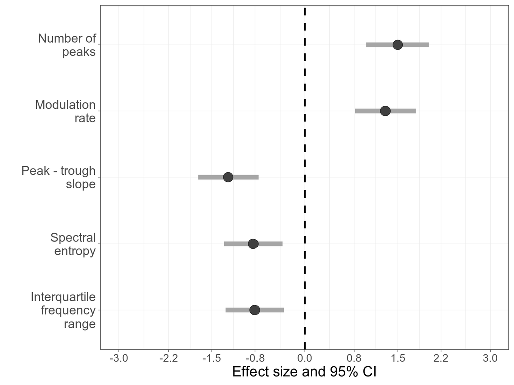

```r
buf <- lim_x/10

# Arrange by order of decreasing absolute effect size
eff_df_tmp %>%
  arrange(abs(effect_size)) %>%
  dplyr::mutate(
    measurement_nm = as.character(measurement_nm),
    # Reorder factor levels for plotting order by decreasing absolute effect size
    measurement_nm = factor(measurement_nm, levels = .$measurement_nm)
  ) %>%
    ggplot(aes(x = effect_size, y = measurement_nm)) +
    geom_errorbar(aes(xmin = lower_95_CI, xmax = upper_95_CI), color = "gray65", size = 2.5, width = 0) +
    geom_point(size = 5, shape = 21, color = "black", fill = "gray25", stroke = 0.25) +
    theme_bw() +
    xlab("Effect size and 95% CI") + ylab("") +
    scale_x_continuous(limits = c(-3, 3), breaks = round(seq(-3, 3, 0.75), 1)) +
    # Add a dotted line at 0
    geom_vline(xintercept = 0, size = 1, linetype = "dashed", color = "black") +
    theme(
      axis.title = element_text(size = 16),
      axis.text.y = element_text(size = 14),
      axis.text.x = element_text(size = 12),
      panel.grid.major = element_line(size = 0.25),
      panel.grid.minor = element_line(size = 0.25),
      axis.ticks = element_line(size = 0.25)
    )
```

Frequency quartiles indicate the distribution of energy across the spectrum. Here quartiles are the 3 frequencies that divide the spectrum per call into 4 even intervals. The 25% quartile represents the frequency at which 25% of total energy in the signal is located below the given frequency. Likewise, the 75% quartile represents the frequency that splits off 75% of the total energy of the call.

The interquartile range represents the difference in frequency between these quartiles, a measurement of the frequency spread of the total energy of the signal. Higher IQR in the invasive range indicates that energy is more spread out over the range of frequency than native range calls.

For spectral entropy, values closer to 1 are noisy signals, values closer to 0 are more tonal. Lower spectral entropy values represent more ordered and informative signals, which ties lower spectral entropy in native range calls to higher frequency modulation levels.

High background noise can affect frequency quantile measurements and spectral entropy<sup>[1]</sup>, but we pre-processed calls using a strict SNR threshold prior to these analyses, so we don’t expect differences in these parameters to arise from differences in background noise between ranges.

## Temporal comparison

Get the invasive range calls set aside for a temporal comparison, as well as native range calls.

```r
calls <- freq_modQ_df %>%
  filter(question == "temporal" | range == "Native") %>%
  filter(question != "indiv_scale") %>% # exclude individual scale calls
  pull(sound.files) %>%
  as.character()

length(calls)
```

```
## [1] 115
```

```r
peaks_temp_df <- peaks_trghs_df3 %>%
  filter(sound.files %in% calls) %>%
  droplevels()
# glimpse(peaks_temp_df)

# 40 native range calls, 75 invasive range calls
peaks_temp_df %>%
  group_by(range) %>%
  dplyr::summarise(
    n_calls = n_distinct(sound.files)
  )
```

```
## # A tibble: 2 x 2
##   range    n_calls
##   <fct>      <int>
## 1 Native        40
## 2 Invasive      75
```

```r
# How many years are represented in the invasive range? 25 calls from 2004, 30 calls for 2011, and 20 2019 calls
peaks_temp_df %>%
  filter(range == "Invasive") %>%
  group_by(year) %>%
  dplyr::summarise(
    n_calls = n_distinct(sound.files)
  )
```

```
## # A tibble: 3 x 2
##   year  n_calls
##   <chr>   <int>
## 1 2004       25
## 2 2011       30
## 3 2019       20
```

```r
# Invasive spatial areas represented?
# Louisiana and Texas, as expected (New Orleans, Austin)
peaks_temp_df %>%
  filter(range == "Invasive") %>%
  group_by(region, dept_state) %>%
  dplyr::summarise(
    n_calls = n_distinct(sound.files)
  )
```

```
## # A tibble: 2 x 3
## # Groups:   region [2]
##   region    dept_state n_calls
##   <chr>     <chr>        <int>
## 1 Southeast Louisiana       25
## 2 Southwest Texas           50
```

```r
# Which invasive range site-years?
# We recorded repeatedly sampled individuals at some of these sites
# But calls from repeatedly sampled individuals used in the final dataset are not included here (see below)
peaks_temp_df %>%
  filter(range == "Invasive") %>%
  group_by(site_year) %>%
  dplyr::summarise(
    n_calls = n_distinct(sound.files)
  )
```

```
## # A tibble: 15 x 2
##    site_year n_calls
##    <chr>       <int>
##  1 BALL_2004       5
##  2 CANA_2004       5
##  3 ELEM_2011       5
##  4 ELEM_2019       5
##  5 FOLS_2004       5
##  6 INTR_2011       5
##  7 INTR_2019       5
##  8 LAKE_2011       5
##  9 MART_2011       5
## 10 MART_2019       5
## 11 ROBE_2011       5
## 12 SOCC_2004       5
## 13 SOCC_2019       5
## 14 VALL_2004       5
## 15 VALL_2011       5
```

```r
# City-years
peaks_temp_df %>%
  filter(range == "Invasive") %>%
  group_by(year, invasive_city) %>%
  dplyr::summarise(
    n_calls = n_distinct(sound.files)
  )
```

```
## # A tibble: 5 x 3
## # Groups:   year [3]
##   year  invasive_city n_calls
##   <chr> <chr>           <int>
## 1 2004  Austin             10
## 2 2004  New Orleans        15
## 3 2011  Austin             20
## 4 2011  New Orleans        10
## 5 2019  Austin             20
```

```r
# Were any calls from known repeatedly sampled individuals used in frequency tracing?
# Yes, but these 2 calls are also from birds that were not retained as repeatedly sampled individuals in the final dataset (not enough calls remained after pre-processing)
unique(peaks_temp_df$sound.files[grep("site_scale", peaks_temp_df$sound.files)])
```

```
## [1] "2011_02_15_ELEM_WRIG1013_17_site_scale.WAV"
## [2] "2011_02_15_ELEM_WRIG1013_10_site_scale.WAV"
```

```r
# These two calls were from INV-UM3 and INV-UM4, not present in calls for the individual scale
# nat_inv_est[grep(paste(peaks_temp_df$sound.files[grep("site_scale", peaks_temp_df$sound.files)], collapse= "|"), nat_inv_est$sound.files), ]

# nat_inv_est %>%
# filter(social_scale == "Individual") %>%
# pull(Bird_ID) %>%
# unique()
```

## Frequency modulation summary statistics

A visual with mean and standard error for the same 5 acoustic measurements with the largest effect sizes identified in the comparison between ranges. Here, get these summary statistics by range-year.

First, get the mean and standard error of frequency modulation measurements per range-year. Modulation must be calculated here, as it is a summary of peaks across calls.

```r
# Iterate over measurements to get summary statistics per range, and effect size of range
ms <- c("Number of peaks", "Modulation rate", "Peak - trough slope")
col_nms <- c("num_peaks", "freq_mod_rate", "peak_trgh_slope")

temp_mean_se_df_fm <- rbindlist(pblapply(1:length(ms), function(i){

  # Get summary statistics and effect sizes depending on measurement type
  if(grepl("Number of peaks", ms[i])){

    tmp_df <- peaks_temp_df %>%
      # Find the number of peaks per call
      group_by(range, year, sound.files) %>%
      dplyr::summarise(
        num_peaks = length(peak_number)
      ) %>%
      ungroup() %>%
      # Ensure levels of the range column are in the expected order
      dplyr::mutate(
        range = as.character(range),
        range = factor(range, levels = c("Native", "Invasive"))
      ) %>%
      # Calculate mean and standard error per range-year
      group_by(range, year) %>%
      dplyr::summarise(
        mean_peaks = mean(num_peaks),
        se_peaks = std_err(num_peaks)
      ) %>%
      # Convert to long format for plotting below
      pivot_longer(
        cols = c(mean_peaks, se_peaks),
        names_to = "type",
        values_to = "values"
      ) %>%
      dplyr::mutate(
        measurement = ms[i],
        statistic = ifelse(grepl("mean", type), "mean_vals", "se_vals")
      ) %>%
      dplyr::select(-c(type)) %>%
      # Make wider to split out the mean and se columns
      pivot_wider(
        names_from = statistic,
        values_from = values
      )

  } else if(grepl("Modulation rate", ms[i])){

    tmp_df <- peaks_temp_df %>%
      # Calculate duration per call
      inner_join(
        freq_mod_df %>%
        dplyr::mutate(
          duration = end - start
        ) %>%
        dplyr::select(sound.files, duration),
        by = "sound.files"
      ) %>%
      # Calculate modulation rate value per call
      group_by(range, year, sound.files, duration) %>%
      dplyr::summarise(
        num_peaks = length(peak_number)
      ) %>%
      ungroup() %>%
      dplyr::mutate(
        modulation_rate = (num_peaks/duration) # units for rate of change = peaks/second
      ) %>%
      # Ensure levels of the range column are in the expected order
      dplyr::mutate(
        range = as.character(range),
        range = factor(range, levels = c("Native", "Invasive"))
      ) %>%
      # Calculate mean and standard error per range-year
      group_by(range, year) %>%
      dplyr::summarise(
        mean_freq_mod_rate = mean(modulation_rate),
        se_freq_mod_rate = std_err(modulation_rate)
      ) %>%
      # Convert to long format for plotting below
      pivot_longer(
        cols = c(mean_freq_mod_rate, se_freq_mod_rate),
        names_to = "type",
        values_to = "values"
      ) %>%
      dplyr::mutate(
        measurement = ms[i],
        statistic = ifelse(grepl("mean", type), "mean_vals", "se_vals")
      ) %>%
      dplyr::select(-c(type)) %>%
      # Make wider to split out the mean and se columns
      pivot_wider(
        names_from = statistic,
        values_from = values
      )

  } else if(grepl("Peak - trough slope", ms[i])){

    tmp_df <- peaks_temp_df %>%
      # Drop peaks that were not matched to troughs
      filter(!is.na(peak_trgh_slope)) %>%
      # Ensure levels of the range column are in the expected order
      dplyr::mutate(
        range = as.character(range),
        range = factor(range, levels = c("Native", "Invasive"))
      ) %>%
      # Get maximum (absolute) peak-trough range per call
      group_by(range, year, sound.files) %>%
      dplyr::summarise(
        max_peak_trgh_slope = min(peak_trgh_slope)
      ) %>%
      ungroup() %>%
      # Calculate mean and standard error per range-year
      group_by(range, year) %>%
      dplyr::summarise(
        mean_pt_slope = mean(max_peak_trgh_slope),
        se_pt_slope = std_err(max_peak_trgh_slope)
      ) %>%
      # Convert to long format for plotting below
      pivot_longer(
        cols = c(mean_pt_slope, se_pt_slope),
        names_to = "type",
        values_to = "values"
      ) %>%
      dplyr::mutate(
        measurement = ms[i],
        statistic = ifelse(grepl("mean", type), "mean_vals", "se_vals")
      ) %>%
      dplyr::select(-c(type)) %>%
      # Make wider to split out the mean and se columns
      pivot_wider(
        names_from = statistic,
        values_from = values
      )
  }

  return(tmp_df)

}))

glimpse(temp_mean_se_df_fm)
```

```
## Rows: 12
## Columns: 5
## $ range       <fct> Native, Invasive, Invasive, Invasive, Native, Invasive, I…
## $ year        <chr> "2017", "2004", "2011", "2019", "2017", "2004", "2011", "…
## $ measurement <chr> "Number of peaks", "Number of peaks", "Number of peaks", …
## $ mean_vals   <dbl> 5.8250000, 4.4000000, 4.3333333, 4.0000000, 33.6421780, 2…
## $ se_vals     <dbl> 0.13815404, 0.20816660, 0.15412589, 0.19194297, 0.7912748…
```

## Summary statistics from other acoustic measurements

Next get mean and standard error per range-year of 15 acoustic measurements used in supervised machine learning.

```r
# Read in the dataset used for supervised machine learning
sup_ML_df <- readRDS(file.path(path, "sup_ML_fin.RDS"))
dim(sup_ML_df)
```

```
## [1] 1561  206
```

```r
# Get the names of raw acoustic parameters used in supervised learning
pnms <- names(sup_ML_df)[which(sapply(sup_ML_df, is.numeric))]
length(pnms[-grep("MDS|PCA", pnms)])
```

```
## [1] 15
```

```r
pnms[-grep("MDS|PCA", pnms)]
```

```
##  [1] "duration"  "freq.Q75"  "freq.IQR"  "time.Q25"  "kurt"      "sp.ent"
##  [7] "mindom"    "maxdom"    "dfrange"   "modindx"   "startdom"  "enddom"
## [13] "dfslope"   "meanpeakf" "peakf"
```

```r
temp_ss_raw_params_df <- sup_ML_df %>%
  # Filter by calls used in the frequency modulation analysis
  filter(sound.files %in% peaks_temp_df$sound.files) %>%
  # Add in year
  inner_join(
    peaks_temp_df %>%
      dplyr::select(sound.files, year),
    by = "sound.files"
  ) %>%
  dplyr::select(range, year, pnms[-grep("MDS|PCA", pnms)]) %>%
  # Convert to long format
  pivot_longer(
    cols = names(.)[-grep("^range$|^year$", names(.))],
    names_to = "measurement",
    values_to = "values"
  ) %>%
  # Get mean and standard error per acoustic measurement per range-year
  group_by(range, year, measurement) %>%
  dplyr::summarise(
    mean_vals = mean(values),
    se_vals = std_err(values)
  ) %>%
  # Convert to long format again for plotting below
  pivot_longer(
    cols = c(mean_vals, se_vals),
    names_to = "type",
    values_to = "values"
  ) %>%
  dplyr::mutate(
    statistic = ifelse(grepl("mean", type), "mean_vals", "se_vals")
  ) %>%
  dplyr::select(-c(type)) %>%
  # Make wider to split out the mean and se columns
  pivot_wider(
    names_from = statistic,
    values_from = values
  ) %>%
  ungroup() %>%
  dplyr::mutate(
    measurement = as.character(measurement),
    range = as.character(range),
    range = factor(range, levels = c("Native", "Invasive"))
  )

glimpse(temp_ss_raw_params_df)
```

```
## Rows: 60
## Columns: 5
## $ range       <fct> Invasive, Invasive, Invasive, Invasive, Invasive, Invasiv…
## $ year        <chr> "2004", "2004", "2004", "2004", "2004", "2004", "2004", "…
## $ measurement <chr> "dfrange", "dfslope", "duration", "enddom", "freq.IQR", "…
## $ mean_vals   <dbl> 4.16818182, 7.58705927, 0.16122598, 2.69500000, 2.3395935…
## $ se_vals     <dbl> 0.0666387019, 1.2562739066, 0.0015559507, 0.1767135549, 0…
```

```r
levels(temp_ss_raw_params_df$range)
```

```
## [1] "Native"   "Invasive"
```

### Supplementary Figure 1

Combine data frames with means and standard errors. For this plot, include both frequency measurements, as well as acoustic parameters used for machine learning that displayed the largest effect sizes of range when comparing between ranges above.

```r
temp_ss_df <- bind_rows(temp_mean_se_df_fm, temp_ss_raw_params_df)
glimpse(temp_ss_df)

# The 5 acoustic measurements with the largest effect sizes? In either direction
# Cohen's rule of thumb for large effect sizes is >= 0.8
topms <- eff_df %>%
  arrange(desc(abs(effect_size))) %>%
  slice(1:5) %>%
  pull(measurement)
topms

# Filter the summary statistics data frame by these variables, and rename these
temp_ss_df_tmp <- temp_ss_df %>%
  filter(measurement %in% topms) %>%
  dplyr::mutate(
    measurement_nm = measurement,
    # Add new line symbols to all measurement names
    measurement_nm = gsub("Number of peaks", "Number of\n peaks", measurement_nm),
    measurement_nm = gsub("Modulation rate", "Modulation\n rate", measurement_nm),
    measurement_nm = gsub("sp.ent", "Spectral\n entropy", measurement_nm),
    measurement_nm = gsub("freq.IQR", "Interquartile\n freq. range", measurement_nm),
    measurement_nm = gsub("Peak - trough slope", "Peak - trough\n slope", measurement_nm),
    measurement_nm = factor(measurement_nm),
    range_year = paste(ifelse(range == "Native", "NAT", "INV"), year, sep = " - "),
    range_year = factor(range_year, levels = c("NAT - 2017", "INV - 2004", "INV - 2011", "INV - 2019"))
  ) %>%
  droplevels()

temp_ss_df_tmp


cols <- scales::alpha(c("navy", "orange"), 0.85)

# Make a list of plots in order of effect sizes
# Doing this to customize y-axes of each plot, which isn't possible for plots in a single row with facetscales
gg_list <- list()

# i <- 2
invisible(pblapply(1:length(topms), function(i){

  tmp_df <- temp_ss_df_tmp %>%
    filter(measurement == topms[i]) %>%
    dplyr::mutate(
      measurement_nm = as.character(measurement_nm),
      measurement_nm = factor(measurement_nm, levels = unique(measurement_nm))
    )
  # Get ymin and ymax values, add a buffer of 2 evenly space values before and after
  ymin <- min(tmp_df$mean_vals)
  ymax <- max(tmp_df$mean_vals)

  # Get the difference between max and min, use this as a buffer on the y-axis scale
  buf <- ymax - ymin

  # If on the first or 4th plot, add the y-axis label
  if(i == 1 | i == 4){
    yal <- "Mean +/- SE"
  } else{
    yal <- ""
  }

  # Initialize plot margins (top, right, bottom, left)
  tm <- -0.5
  rm <- 0
  bm <- 1
  lm <- 0

  # If on the first or 4th plot, make the left margin larger
  if(i == 1 | i == 4){
    lm <- 0.5
  # If on last plot, make the right margin larger
  } else if(i == length(topms)){
    rm <- 0.5
  }

  gg <- tmp_df %>%
    ggplot(aes(x = range_year, y = mean_vals)) +
    geom_errorbar(aes(ymin = mean_vals - se_vals, ymax = mean_vals + se_vals, color = range), size = 2.5, width = 0.5) +
    geom_point(size = 4, shape = 21, fill = "gray65", stroke = 0.25) +
    facet_wrap(~ measurement_nm, nrow = 1) +
    scale_color_manual(values = cols) +
    theme_bw() +
    guides(color = FALSE) +
    xlab("") + ylab(yal) +
    scale_y_continuous(limits = round(c(ymin - buf, ymax + buf), 2), breaks = round(seq((ymin - buf), (ymax + buf), (ymax - ymin)/2), 2)) +
    theme(
      axis.title = element_text(size = 18),
      axis.text.y = element_text(size = 14),
      axis.text.x = element_text(size = 14, angle = 40, hjust = 1),
      strip.text = element_text(size = 16, margin = margin(1, 1, 1, 1, "lines")),
      panel.grid.major = element_line(size = 0.25),
      panel.grid.minor = element_line(size = 0.25),
      axis.ticks = element_line(size = 0.25),
      plot.margin = unit(c(tm, rm, bm, lm), "lines")
    )

  # gg

  # Return the given plot
  gg_list[[i]] <<- gg

}))

# Get the legend
gg_leg <- gtable::gtable_filter(ggplot_gtable(ggplot_build(
  temp_ss_df_tmp %>%
    ggplot(aes(x = range, y = mean_vals)) +
    geom_errorbar(aes(ymin = mean_vals - se_vals, ymax = mean_vals + se_vals, color = range), size = 2, width = 0.25) +
    scale_color_manual(values = cols) +
    guides(color = guide_legend(title = "", override.aes = list(size = 3))) +
    theme_bw() +
    theme(
      legend.text = element_text(size = 16),
      legend.position = "top",
      legend.margin = margin(0, 0, 0, 0),
      legend.box.margin = margin(-10, -10, -10, -10),
      legend.key.width = unit(3, "lines")
    )
)), "guide-box")

dev.off()

# Arrange the legend and plots into a single image file
jpeg(file.path(gpath, "SupplementaryFigure01_TemporalMeanSE_AcousticParams.jpeg"), units = "in", width = 8.5, height = 10, res = 300)
ggarrange(
  as.ggplot(gg_leg),
  as.ggplot(ggarrange(
    as.ggplot(gg_list[[1]]),
    as.ggplot(gg_list[[2]]),
    as.ggplot(gg_list[[3]]),
    as.ggplot(gg_list[[4]]),
    as.ggplot(gg_list[[5]]),
    nrow = 2,
    widths = rep(2.83, 3),
    heights = c(5, 5)
  )),
  nrow = 2,
  heights = c(1, 9)
)
dev.off()
```

See supplementary methods for this figure, which shows that structural differentiation among years in the invasive range were not comparable to the level of structural differentiation we reported between ranges for these same acoustic measurements.

# References

```
1. Araya-Salas, M., Smith-Vidaurre, G., and M. Webster. 2017. Assessing the effect of sound file compression and background noise on measures of acoustic signal structure. Bioacoustics 28(1), 57-73.
```